```python
import musicntd.scripts.hide_code as hide
```

# Distribution of segments' sizes in MIREX10

The study of the MIREX10 annotations in [1] shows that segments in this dataset are regular, and mostly centered around the size of 16 onbeats.

We replicated these results by studying the size in number of bars, more adapted to our context.

```
Number of segments: 1619
```

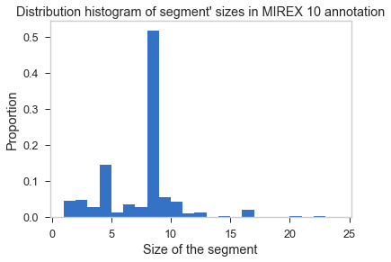

```python
hide.repartition_bar_lengths_RWCPop()
```

We see in this histogram that most of the segment (more than a half) last 8 bars, and that numerous other segments last 4 bars. The other values are less represented. Hence, it should be interesting to enforce these sizes in our algorithm.

Thus, we modified our algorithm to include a regularization function, which favoures certain sizes of segments.

This regularization function only depends on the size of the segment, and is subtracted to the convolution cost. Hence, it's a penalty added to the raw convolution cost. Denoting $c_{b_1, b_2}$ the convolution cost as defined previously (see Notebook 1 or the Appendix which details our algorithm), the "regularized" cost is defined as $c'_{b_1,b_2} = c_{b_1,b_2} - \lambda p(b_2 - b_1 + 1) c_{k8}^{max}$, with:

- $p(b_2 - b_1 + 1)$ the regularization function, which we will present in next part,
- $\lambda$, a ponderation to handle the influence of this function,
- $c_{k8}^{max}$, which represents the maximal convolution score on all intervals of size 8 of the current song, and its associated autosimilarity matrix. The idea of this score is to adapt the penalty to the specific shape of this autosimilarity. It can analogously be seen as a normalization of the raw convolution score: $\frac{c_{b_1,b_2}}{ c_{k8}^{max}} - \lambda p(b_2 - b_1 + 1)$

In this notebook, we will try to define the function $p$ and to study the influence of the parameter $\lambda$.

# Definition of the regularization functions

We developped two types of regularization functions:

- **Symmetric functions centered on 8, as in [1]**: the idea of this method is to favoure segments lasting 8 bars, as the majority of segments have this size, and to penalize all the other segments as the difference between their size and 8, raised to a certain power. Concretely, this results in:

  $p(n) = |n - 8| ^{\alpha}$

  with $n$ the size of the segment. Here, $\alpha$ is a parameter, and we will try
  - $\alpha = \frac{1}{2}$
  - $\alpha = 1$
  - $\alpha = 2$
- **"Modulo functions"**: the idea of this method is to enforce specific sizes of segments, based on prior knowledge. They may be more empirical, but are also more adaptable to the need. Our main idea when developping this function was to favoure 8 wihout penalizing too much 4 or 16, that we know are current sizes (especially 4 in RWC Pop, as shown above). In addition, we considered that segments of even sizes should appear more often than segments of odd sizes in western pop music, which is less obvious in the distribution from above.

  We will try 3 different types of function:
  - "Favouring modulo 4": in this case:
    - if $n \equiv 0 \pmod 4, p(n) = 0$,
    - else, if $n \equiv 0 \pmod 2, p(n) = \frac{1}{2}$,
    - else, $p(n) = 1$.
  - "Favouring 8, then modulo 4": in this case:
    - if $n = 8, p(n) = 0$,
    - else, if $n \equiv 0 \pmod 4, p(n) = \frac{1}{4}$,
    - else, if $n \equiv 0 \pmod 2, p(n) = \frac{1}{2}$,
    - else, $p(n) = 1$.
  - "Favouring little segments of 8, then 4": in this case:
    - if $n > 12, p(n) = 100$ (we forbid the algorithm to select segments lasting more than 12 bars),
    - else, if $n = 8, p(n) = 0$,
    - else, if $n \equiv 0 \pmod 4, p(n) = \frac{1}{4}$,
    - else, if $n \equiv 0 \pmod 2, p(n) = \frac{1}{2}$,
    - else, $p(n) = 1$.

We will now test all these functions on the entire RWC Pop database.

- First, we will fix the ranks to $T' = 32$ (rank for factor $H$) and $B' = 32$ (rank for factor $Q$), and search for the best $\lambda$ in this condition. **In this condition, scores will only be plotted for the tolerance window of 0.5 seconds**.
- Secondly, we will keep the best parameter $\lambda$ for the ranks 32,32, and we will try several values of ranks with this $\lambda$ fixed. **In this condition, we will show scores with both tolerances 0.5 seconds and 3 seconds, in that order**.

As stated in the previous notebook, we now fix the subdivision to 96.

```python
subdivision = 96
```

# Estimating $\lambda$, with fixed ranks $T' = 32$ and $B' = 32$

## Symmetric functions centered on 8

### $\alpha = \frac{1}{2}$

```python
param_range = [i/100 for i in range(0,100,5)]
hide.convolution_parameter_on_all_rwc(param_range, subdivision = subdivision, penalty_func = "sargentdemi")
```

```
c:\users\amarmore\desktop\projects\phd main projects\on git\code\tensor factorization\musicntd\autosimilarity_segmentation.py:43: RuntimeWarning: invalid value encountered in true_divide
  this_array = np.array([list(i/np.linalg.norm(i)) for i in this_array.T]).T
```

|  | Vrai Positifs | Faux Positifs | Faux Négatifs | Precision | Rappel | F mesure |
| --- | --- | --- | --- | --- | --- | --- |
| 0.0 | 10.9400 | 11.7800 | 7.8700 | 0.4876 | 0.5922 | 0.5259 |
| 0.05 | 10.4800 | 9.8400 | 8.3300 | 0.5229 | 0.5663 | 0.5347 |
| 0.1 | 10.2200 | 8.6800 | 8.5900 | 0.5459 | 0.5514 | 0.5413 |
| 0.15 | 10.0100 | 7.8700 | 8.8000 | 0.5641 | 0.5403 | 0.5450 |
| 0.2 | 9.8500 | 7.2200 | 8.9600 | 0.5799 | 0.5307 | 0.5479 |
| 0.25 | 9.7200 | 6.7200 | 9.0900 | 0.5917 | 0.5231 | 0.5495 |
| 0.3 | 9.5900 | 6.3800 | 9.2200 | 0.5999 | 0.5159 | 0.5495 |
| 0.35 | 9.5300 | 6.3200 | 9.2800 | 0.6016 | 0.5146 | 0.5494 |
| 0.4 | 9.4600 | 6.1300 | 9.3500 | 0.6069 | 0.5115 | 0.5502 |
| 0.45 | 9.3900 | 6.2300 | 9.4200 | 0.6028 | 0.5076 | 0.5463 |
| 0.5 | 9.2300 | 6.3200 | 9.5800 | 0.5950 | 0.4975 | 0.5368 |
| 0.55 | 9.1300 | 6.5200 | 9.6800 | 0.5854 | 0.4924 | 0.5298 |
| 0.6 | 9.2200 | 6.5500 | 9.5900 | 0.5864 | 0.4965 | 0.5330 |
| 0.65 | 9.2200 | 6.7400 | 9.5900 | 0.5800 | 0.4958 | 0.5295 |
| 0.7 | 9.2100 | 6.8600 | 9.6000 | 0.5753 | 0.4940 | 0.5268 |
| 0.75 | 9.1000 | 7.0000 | 9.7100 | 0.5664 | 0.4894 | 0.5206 |
| 0.8 | 9.0400 | 7.1700 | 9.7700 | 0.5616 | 0.4863 | 0.5167 |
| 0.85 | 8.9900 | 7.3500 | 9.8200 | 0.5563 | 0.4841 | 0.5131 |
| 0.9 | 9.0000 | 7.3500 | 9.8100 | 0.5554 | 0.4852 | 0.5133 |
| 0.95 | 8.9600 | 7.4600 | 9.8500 | 0.5518 | 0.4828 | 0.5103 |

For $\alpha = \frac{1}{2}$, the best $\lambda$ (in our range) seems to be **0.4**.

### $\alpha = 1$

```python
param_range = [i/1000 for i in range(0,100, 5)]
hide.convolution_parameter_on_all_rwc(param_range, subdivision = subdivision, penalty_func = "sargentun")
```

|  | Vrai Positifs | Faux Positifs | Faux Négatifs | Precision | Rappel | F mesure |
| --- | --- | --- | --- | --- | --- | --- |
| 0.0 | 10.9400 | 11.7800 | 7.8700 | 0.4876 | 0.5922 | 0.5259 |
| 0.005 | 10.8000 | 10.9700 | 8.0100 | 0.5013 | 0.5840 | 0.5304 |
| 0.01 | 10.6900 | 10.5700 | 8.1200 | 0.5085 | 0.5783 | 0.5321 |
| 0.015 | 10.5900 | 10.2600 | 8.2200 | 0.5146 | 0.5724 | 0.5329 |
| 0.02 | 10.5500 | 9.9900 | 8.2600 | 0.5191 | 0.5700 | 0.5346 |
| 0.025 | 10.4800 | 9.7600 | 8.3300 | 0.5238 | 0.5657 | 0.5356 |
| 0.03 | 10.4800 | 9.5400 | 8.3300 | 0.5295 | 0.5658 | 0.5390 |
| 0.035 | 10.3100 | 9.3000 | 8.5000 | 0.5319 | 0.5568 | 0.5365 |
| 0.04 | 10.1800 | 9.1400 | 8.6300 | 0.5325 | 0.5498 | 0.5337 |
| 0.045 | 10.0900 | 8.9900 | 8.7200 | 0.5341 | 0.5443 | 0.5318 |
| 0.05 | 10.1000 | 8.7600 | 8.7100 | 0.5404 | 0.5444 | 0.5352 |
| 0.055 | 9.9600 | 8.6800 | 8.8500 | 0.5388 | 0.5373 | 0.5313 |
| 0.06 | 9.9200 | 8.5500 | 8.8900 | 0.5419 | 0.5359 | 0.5323 |
| 0.065 | 9.8700 | 8.3300 | 8.9400 | 0.5464 | 0.5330 | 0.5331 |
| 0.07 | 9.8400 | 8.2300 | 8.9700 | 0.5489 | 0.5309 | 0.5337 |
| 0.075 | 9.8500 | 8.0800 | 8.9600 | 0.5538 | 0.5310 | 0.5363 |
| 0.08 | 9.8000 | 7.9100 | 9.0100 | 0.5571 | 0.5283 | 0.5366 |
| 0.085 | 9.7900 | 7.7900 | 9.0200 | 0.5611 | 0.5276 | 0.5382 |
| 0.09 | 9.7700 | 7.6700 | 9.0400 | 0.5647 | 0.5266 | 0.5394 |
| 0.095 | 9.7000 | 7.6500 | 9.1100 | 0.5621 | 0.5226 | 0.5364 |

For $\alpha = 1$, the best $\lambda$ seems to be **0.09**.

### $\alpha = 2$

```python
param_range = [i/1000 for i in range(0,20)]
hide.convolution_parameter_on_all_rwc(param_range, subdivision = subdivision, penalty_func = "sargentdeux")
```

|  | Vrai Positifs | Faux Positifs | Faux Négatifs | Precision | Rappel | F mesure |
| --- | --- | --- | --- | --- | --- | --- |
| 0.0 | 10.9400 | 11.7800 | 7.8700 | 0.4876 | 0.5922 | 0.5259 |
| 0.001 | 10.8100 | 10.9800 | 8.0000 | 0.5023 | 0.5841 | 0.5312 |
| 0.002 | 10.6700 | 10.6800 | 8.1400 | 0.5059 | 0.5769 | 0.5305 |
| 0.003 | 10.6000 | 10.4600 | 8.2100 | 0.5094 | 0.5729 | 0.5310 |
| 0.004 | 10.5800 | 10.3000 | 8.2300 | 0.5129 | 0.5712 | 0.5327 |
| 0.005 | 10.4600 | 10.0500 | 8.3500 | 0.5161 | 0.5647 | 0.5321 |
| 0.006 | 10.3100 | 9.8600 | 8.5000 | 0.5173 | 0.5571 | 0.5299 |
| 0.007 | 10.2600 | 9.6600 | 8.5500 | 0.5206 | 0.5540 | 0.5308 |
| 0.008 | 10.1500 | 9.6600 | 8.6600 | 0.5181 | 0.5475 | 0.5268 |
| 0.009 | 10.0600 | 9.5600 | 8.7500 | 0.5185 | 0.5419 | 0.5246 |
| 0.01 | 9.9600 | 9.4500 | 8.8500 | 0.5187 | 0.5372 | 0.5222 |
| 0.011 | 9.8800 | 9.3800 | 8.9300 | 0.5182 | 0.5330 | 0.5201 |
| 0.012 | 9.8000 | 9.2200 | 9.0100 | 0.5199 | 0.5286 | 0.5192 |
| 0.013 | 9.7100 | 9.1100 | 9.1000 | 0.5196 | 0.5245 | 0.5172 |
| 0.014 | 9.6300 | 9.0400 | 9.1800 | 0.5203 | 0.5199 | 0.5155 |
| 0.015 | 9.5900 | 9.0200 | 9.2200 | 0.5196 | 0.5183 | 0.5145 |
| 0.016 | 9.5100 | 8.9600 | 9.3000 | 0.5192 | 0.5145 | 0.5125 |
| 0.017 | 9.4700 | 8.9200 | 9.3400 | 0.5199 | 0.5122 | 0.5117 |
| 0.018 | 9.4600 | 8.8500 | 9.3500 | 0.5214 | 0.5113 | 0.5119 |
| 0.019 | 9.4100 | 8.8400 | 9.4000 | 0.5203 | 0.5087 | 0.5100 |

For $\alpha = 2$, the best $\lambda$ seems to be **0.004**.

## Modulo functions

### "Favouring modulo 4"

```python
param_range = [i/10 for i in range(0,20)]
hide.convolution_parameter_on_all_rwc(param_range, subdivision = subdivision, penalty_func = "modulo4")
```

|  | Vrai Positifs | Faux Positifs | Faux Négatifs | Precision | Rappel | F mesure |
| --- | --- | --- | --- | --- | --- | --- |
| 0.0 | 10.9400 | 11.7800 | 7.8700 | 0.4876 | 0.5922 | 0.5259 |
| 0.1 | 10.8700 | 10.2700 | 7.9400 | 0.5193 | 0.5877 | 0.5424 |
| 0.2 | 10.7200 | 9.2700 | 8.0900 | 0.5415 | 0.5794 | 0.5510 |
| 0.3 | 10.7600 | 8.3500 | 8.0500 | 0.5682 | 0.5802 | 0.5655 |
| 0.4 | 10.6300 | 7.7700 | 8.1800 | 0.5812 | 0.5737 | 0.5692 |
| 0.5 | 10.4000 | 7.6400 | 8.4100 | 0.5782 | 0.5607 | 0.5618 |
| 0.6 | 10.3800 | 7.2400 | 8.4300 | 0.5897 | 0.5589 | 0.5671 |
| 0.7 | 10.2200 | 7.2000 | 8.5900 | 0.5874 | 0.5499 | 0.5612 |
| 0.8 | 10.2600 | 6.9700 | 8.5500 | 0.5958 | 0.5527 | 0.5665 |
| 0.9 | 10.2700 | 6.7600 | 8.5400 | 0.6029 | 0.5534 | 0.5703 |
| 1.0 | 10.1000 | 6.7300 | 8.7100 | 0.5989 | 0.5455 | 0.5646 |
| 1.1 | 9.9200 | 6.7600 | 8.8900 | 0.5948 | 0.5357 | 0.5579 |
| 1.2 | 9.8500 | 6.6300 | 8.9600 | 0.5963 | 0.5316 | 0.5563 |
| 1.3 | 9.8200 | 6.5400 | 8.9900 | 0.6002 | 0.5310 | 0.5576 |
| 1.4 | 9.6200 | 6.6600 | 9.1900 | 0.5882 | 0.5204 | 0.5466 |
| 1.5 | 9.5700 | 6.5800 | 9.2400 | 0.5893 | 0.5183 | 0.5460 |
| 1.6 | 9.5500 | 6.5500 | 9.2600 | 0.5892 | 0.5170 | 0.5453 |
| 1.7 | 9.2500 | 6.7600 | 9.5600 | 0.5742 | 0.5030 | 0.5309 |
| 1.8 | 9.1500 | 6.8000 | 9.6600 | 0.5698 | 0.4965 | 0.5254 |
| 1.9 | 9.1600 | 6.7900 | 9.6500 | 0.5707 | 0.4970 | 0.5262 |

In this function, the best $\lambda$ seems to be **0.9**.

### "Favouring 8, then modulo 4"

```python
param_range = [i/10 for i in range(0,20)]
hide.convolution_parameter_on_all_rwc(param_range, subdivision = subdivision, penalty_func = "modulo8")
```

|  | Vrai Positifs | Faux Positifs | Faux Négatifs | Precision | Rappel | F mesure |
| --- | --- | --- | --- | --- | --- | --- |
| 0.0 | 10.9400 | 11.7800 | 7.8700 | 0.4876 | 0.5922 | 0.5259 |
| 0.1 | 10.8100 | 10.1700 | 8.0000 | 0.5207 | 0.5846 | 0.5418 |
| 0.2 | 10.6500 | 9.2300 | 8.1600 | 0.5424 | 0.5757 | 0.5490 |
| 0.3 | 10.6900 | 8.3300 | 8.1200 | 0.5680 | 0.5771 | 0.5635 |
| 0.4 | 10.4400 | 7.7600 | 8.3700 | 0.5774 | 0.5627 | 0.5620 |
| 0.5 | 10.3100 | 7.4400 | 8.5000 | 0.5837 | 0.5540 | 0.5611 |
| 0.6 | 10.2200 | 7.0400 | 8.5900 | 0.5942 | 0.5483 | 0.5634 |
| 0.7 | 10.0600 | 6.9400 | 8.7500 | 0.5925 | 0.5414 | 0.5591 |
| 0.8 | 10.0800 | 6.6800 | 8.7300 | 0.6023 | 0.5428 | 0.5644 |
| 0.9 | 10.0800 | 6.3200 | 8.7300 | 0.6146 | 0.5420 | 0.5698 |
| 1.0 | 10.1100 | 6.0400 | 8.7000 | 0.6266 | 0.5450 | 0.5767 |
| 1.1 | 9.9900 | 5.9800 | 8.8200 | 0.6252 | 0.5392 | 0.5728 |
| 1.2 | 9.8100 | 5.8800 | 9.0000 | 0.6242 | 0.5301 | 0.5677 |
| 1.3 | 9.7200 | 5.8800 | 9.0900 | 0.6213 | 0.5242 | 0.5631 |
| 1.4 | 9.6100 | 5.7800 | 9.2000 | 0.6202 | 0.5188 | 0.5591 |
| 1.5 | 9.3400 | 5.8500 | 9.4700 | 0.6118 | 0.5050 | 0.5474 |
| 1.6 | 9.2500 | 5.7000 | 9.5600 | 0.6148 | 0.4999 | 0.5459 |
| 1.7 | 9.0900 | 5.7800 | 9.7200 | 0.6058 | 0.4914 | 0.5372 |
| 1.8 | 8.9000 | 5.8800 | 9.9100 | 0.5974 | 0.4813 | 0.5277 |
| 1.9 | 8.6200 | 6.0600 | 10.1900 | 0.5851 | 0.4680 | 0.5145 |

In this function, the best $\lambda$ seems to be **1**.

### "Favouring little segments of 8, then 4"

```python
param_range = [i/10 for i in range(0,20)]
hide.convolution_parameter_on_all_rwc(param_range, subdivision = subdivision, penalty_func = "moduloSmall8and4")
```

|  | Vrai Positifs | Faux Positifs | Faux Négatifs | Precision | Rappel | F mesure |
| --- | --- | --- | --- | --- | --- | --- |
| 0.0 | 10.9400 | 11.7800 | 7.8700 | 0.4876 | 0.5922 | 0.5259 |
| 0.1 | 11.0100 | 12.8000 | 7.8000 | 0.4679 | 0.5944 | 0.5176 |
| 0.2 | 10.9100 | 11.8400 | 7.9000 | 0.4875 | 0.5891 | 0.5268 |
| 0.3 | 10.8000 | 10.9600 | 8.0100 | 0.5032 | 0.5827 | 0.5336 |
| 0.4 | 10.6200 | 10.5600 | 8.1900 | 0.5081 | 0.5723 | 0.5327 |
| 0.5 | 10.5300 | 10.1700 | 8.2800 | 0.5138 | 0.5653 | 0.5331 |
| 0.6 | 10.4900 | 9.8100 | 8.3200 | 0.5218 | 0.5626 | 0.5363 |
| 0.7 | 10.4800 | 9.4700 | 8.3300 | 0.5300 | 0.5623 | 0.5408 |
| 0.8 | 10.5100 | 9.1800 | 8.3000 | 0.5383 | 0.5637 | 0.5459 |
| 0.9 | 10.5000 | 8.8900 | 8.3100 | 0.5455 | 0.5626 | 0.5493 |
| 1.0 | 10.5400 | 8.6100 | 8.2700 | 0.5547 | 0.5643 | 0.5553 |
| 1.1 | 10.4600 | 8.5100 | 8.3500 | 0.5549 | 0.5612 | 0.5541 |
| 1.2 | 10.2400 | 8.6300 | 8.5700 | 0.5457 | 0.5492 | 0.5437 |
| 1.3 | 10.1900 | 8.6300 | 8.6200 | 0.5434 | 0.5473 | 0.5416 |
| 1.4 | 10.0700 | 8.6900 | 8.7400 | 0.5399 | 0.5421 | 0.5374 |
| 1.5 | 9.9500 | 8.7100 | 8.8600 | 0.5367 | 0.5365 | 0.5330 |
| 1.6 | 9.7100 | 8.8000 | 9.1000 | 0.5280 | 0.5231 | 0.5220 |
| 1.7 | 9.6000 | 8.7800 | 9.2100 | 0.5258 | 0.5171 | 0.5177 |
| 1.8 | 9.4100 | 8.9100 | 9.4000 | 0.5180 | 0.5079 | 0.5094 |
| 1.9 | 9.3900 | 8.9200 | 9.4200 | 0.5170 | 0.5069 | 0.5083 |

In this function, the best $\lambda$ seems to be **1**.

# Results with different ranks, $\lambda$ fixed

Now, we will fix $\lambda$ to the previous optimal value, and try different ranks for the decomposition.

For both $H$ and $Q$, we will try ranks in the range [12,16,20,24,28,32,36].

```python
ranks_rhythm = [12,16,20,24,28,32,36]
ranks_pattern = [12,16,20,24,28,32,36]
```

Note: I conceed that tables are a bit long, you can jump directly to the conclusion to see what we considered to be the best outputs, and check if it's coherent in the tables afterwards.

## Symmetric functions centered on 8

### $\alpha = 1/2$

```python
zero_five_chr, three_chr = hide.compute_ranks_RWC(ranks_rhythm,ranks_pattern,subdivision=subdivision,
                                                  penalty_weight = 0.4, penalty_func = "sargentdemi")
```

|  | Résultats à 0.5 secondes | Vrai Positifs | Faux Positifs | Faux Négatifs | Precision | Rappel | F mesure |
| --- | --- | --- | --- | --- | --- | --- | --- |
| Rang Q:12 | Rang H:12 | 7.8800 | 5.7800 | 10.9300 | 0.5773 | 0.4246 | 0.4825 |
|  | Rang H:16 | 7.8200 | 6.0000 | 10.9900 | 0.5634 | 0.4228 | 0.4766 |
|  | Rang H:20 | 8.0400 | 5.9000 | 10.7700 | 0.5755 | 0.4338 | 0.4886 |
|  | Rang H:24 | 8.1600 | 5.8700 | 10.6500 | 0.5798 | 0.4384 | 0.4922 |
|  | Rang H:28 | 8.2900 | 5.9900 | 10.5200 | 0.5837 | 0.4467 | 0.4991 |
|  | Rang H:32 | 7.9700 | 5.9300 | 10.8400 | 0.5715 | 0.4291 | 0.4837 |
|  | Rang H:36 | 8.2100 | 5.9900 | 10.6000 | 0.5766 | 0.4420 | 0.4938 |
| Rang Q:16 | Rang H:12 | 8.4100 | 5.9400 | 10.4000 | 0.5813 | 0.4531 | 0.5032 |
|  | Rang H:16 | 8.7000 | 5.8500 | 10.1100 | 0.5969 | 0.4688 | 0.5193 |
|  | Rang H:20 | 8.9600 | 5.7100 | 9.8500 | 0.6046 | 0.4825 | 0.5313 |
|  | Rang H:24 | 8.7900 | 5.8400 | 10.0200 | 0.5992 | 0.4743 | 0.5234 |
|  | Rang H:28 | 8.7500 | 5.8900 | 10.0600 | 0.5940 | 0.4696 | 0.5192 |
|  | Rang H:32 | 8.8200 | 5.6400 | 9.9900 | 0.6047 | 0.4750 | 0.5268 |
|  | Rang H:36 | 8.8700 | 5.9000 | 9.9400 | 0.5977 | 0.4760 | 0.5242 |
| Rang Q:20 | Rang H:12 | 8.9800 | 5.6000 | 9.8300 | 0.6159 | 0.4829 | 0.5354 |
|  | Rang H:16 | 9.0300 | 5.9800 | 9.7800 | 0.5980 | 0.4861 | 0.5302 |
|  | Rang H:20 | 9.0700 | 6.0000 | 9.7400 | 0.5995 | 0.4893 | 0.5336 |
|  | Rang H:24 | 9.1800 | 5.8600 | 9.6300 | 0.6077 | 0.4947 | 0.5393 |
|  | Rang H:28 | 9.1500 | 5.8900 | 9.6600 | 0.6063 | 0.4927 | 0.5373 |
|  | Rang H:32 | 9.1700 | 5.9000 | 9.6400 | 0.6078 | 0.4935 | 0.5384 |
|  | Rang H:36 | 9.1000 | 6.0200 | 9.7100 | 0.6025 | 0.4906 | 0.5349 |
| Rang Q:24 | Rang H:12 | 8.9100 | 6.0500 | 9.9000 | 0.5928 | 0.4813 | 0.5254 |
|  | Rang H:16 | 9.3000 | 5.9200 | 9.5100 | 0.6115 | 0.5025 | 0.5459 |
|  | Rang H:20 | 9.3400 | 6.0000 | 9.4700 | 0.6108 | 0.5045 | 0.5475 |
|  | Rang H:24 | 9.5000 | 6.0000 | 9.3100 | 0.6127 | 0.5135 | 0.5530 |
|  | Rang H:28 | 9.2800 | 6.0800 | 9.5300 | 0.6031 | 0.4994 | 0.5410 |
|  | Rang H:32 | 9.2900 | 5.9700 | 9.5200 | 0.6088 | 0.4999 | 0.5441 |
|  | Rang H:36 | 9.4000 | 6.0200 | 9.4100 | 0.6056 | 0.5060 | 0.5464 |
| Rang Q:28 | Rang H:12 | 9.1900 | 5.7500 | 9.6200 | 0.6141 | 0.4971 | 0.5440 |
|  | Rang H:16 | 9.1500 | 6.2500 | 9.6600 | 0.5900 | 0.4913 | 0.5310 |
|  | Rang H:20 | 9.3400 | 6.1100 | 9.4700 | 0.6018 | 0.5015 | 0.5421 |
|  | Rang H:24 | 9.4300 | 6.0400 | 9.3800 | 0.6066 | 0.5062 | 0.5466 |
|  | Rang H:28 | 9.5300 | 5.9500 | 9.2800 | 0.6135 | 0.5125 | 0.5534 |
|  | Rang H:32 | 9.3900 | 5.9000 | 9.4200 | 0.6129 | 0.5050 | 0.5484 |
|  | Rang H:36 | 9.6200 | 5.9300 | 9.1900 | 0.6169 | 0.5175 | 0.5578 |
| Rang Q:32 | Rang H:12 | 9.4000 | 5.7200 | 9.4100 | 0.6226 | 0.5063 | 0.5532 |
|  | Rang H:16 | 9.5000 | 5.8700 | 9.3100 | 0.6190 | 0.5123 | 0.5548 |
|  | Rang H:20 | 9.5200 | 6.0900 | 9.2900 | 0.6085 | 0.5107 | 0.5495 |
|  | Rang H:24 | 9.5600 | 6.1900 | 9.2500 | 0.6059 | 0.5140 | 0.5508 |
|  | Rang H:28 | 9.5900 | 6.1600 | 9.2200 | 0.6084 | 0.5151 | 0.5518 |
|  | Rang H:32 | 9.4600 | 6.1300 | 9.3500 | 0.6069 | 0.5115 | 0.5502 |
|  | Rang H:36 | 9.3400 | 6.3000 | 9.4700 | 0.5966 | 0.5028 | 0.5408 |
| Rang Q:36 | Rang H:12 | 9.1900 | 6.2600 | 9.6200 | 0.5944 | 0.4931 | 0.5338 |
|  | Rang H:16 | 9.2000 | 6.3300 | 9.6100 | 0.5909 | 0.4934 | 0.5325 |
|  | Rang H:20 | 9.3500 | 6.3600 | 9.4600 | 0.5948 | 0.5011 | 0.5392 |
|  | Rang H:24 | 9.4000 | 6.3600 | 9.4100 | 0.5963 | 0.5060 | 0.5425 |
|  | Rang H:28 | 9.3300 | 6.7600 | 9.4800 | 0.5808 | 0.5015 | 0.5334 |
|  | Rang H:32 | 9.3600 | 6.6700 | 9.4500 | 0.5815 | 0.5007 | 0.5333 |
|  | Rang H:36 | 9.3300 | 6.6200 | 9.4800 | 0.5845 | 0.5010 | 0.5354 |

|  | Résultats à 3 secondes | Vrai Positifs | Faux Positifs | Faux Négatifs | Precision | Rappel | F mesure |
| --- | --- | --- | --- | --- | --- | --- | --- |
| Rang Q:12 | Rang H:12 | 10.0500 | 3.6100 | 8.7600 | 0.7384 | 0.5412 | 0.6161 |
|  | Rang H:16 | 10.3800 | 3.4400 | 8.4300 | 0.7510 | 0.5595 | 0.6327 |
|  | Rang H:20 | 10.5600 | 3.3800 | 8.2500 | 0.7608 | 0.5687 | 0.6428 |
|  | Rang H:24 | 10.5500 | 3.4800 | 8.2600 | 0.7548 | 0.5675 | 0.6388 |
|  | Rang H:28 | 10.7200 | 3.5600 | 8.0900 | 0.7574 | 0.5781 | 0.6469 |
|  | Rang H:32 | 10.1400 | 3.7600 | 8.6700 | 0.7288 | 0.5451 | 0.6156 |
|  | Rang H:36 | 10.6600 | 3.5400 | 8.1500 | 0.7522 | 0.5727 | 0.6418 |
| Rang Q:16 | Rang H:12 | 10.6600 | 3.6900 | 8.1500 | 0.7426 | 0.5733 | 0.6392 |
|  | Rang H:16 | 11.1500 | 3.4000 | 7.6600 | 0.7678 | 0.5996 | 0.6656 |
|  | Rang H:20 | 11.4500 | 3.2200 | 7.3600 | 0.7798 | 0.6172 | 0.6816 |
|  | Rang H:24 | 11.2700 | 3.3600 | 7.5400 | 0.7738 | 0.6067 | 0.6720 |
|  | Rang H:28 | 11.2800 | 3.3600 | 7.5300 | 0.7705 | 0.6064 | 0.6715 |
|  | Rang H:32 | 11.1400 | 3.3200 | 7.6700 | 0.7663 | 0.5984 | 0.6651 |
|  | Rang H:36 | 11.4300 | 3.3400 | 7.3800 | 0.7755 | 0.6129 | 0.6772 |
| Rang Q:20 | Rang H:12 | 11.1600 | 3.4200 | 7.6500 | 0.7671 | 0.5998 | 0.6655 |
|  | Rang H:16 | 11.6000 | 3.4100 | 7.2100 | 0.7728 | 0.6246 | 0.6827 |
|  | Rang H:20 | 11.6500 | 3.4200 | 7.1600 | 0.7753 | 0.6266 | 0.6861 |
|  | Rang H:24 | 11.5900 | 3.4500 | 7.2200 | 0.7735 | 0.6229 | 0.6820 |
|  | Rang H:28 | 11.7300 | 3.3100 | 7.0800 | 0.7822 | 0.6335 | 0.6916 |
|  | Rang H:32 | 11.3500 | 3.7200 | 7.4600 | 0.7546 | 0.6105 | 0.6670 |
|  | Rang H:36 | 11.5500 | 3.5700 | 7.2600 | 0.7679 | 0.6221 | 0.6795 |
| Rang Q:24 | Rang H:12 | 11.1900 | 3.7700 | 7.6200 | 0.7488 | 0.6028 | 0.6603 |
|  | Rang H:16 | 11.8000 | 3.4200 | 7.0100 | 0.7805 | 0.6374 | 0.6940 |
|  | Rang H:20 | 11.7200 | 3.6200 | 7.0900 | 0.7673 | 0.6315 | 0.6861 |
|  | Rang H:24 | 12.0200 | 3.4800 | 6.7900 | 0.7786 | 0.6477 | 0.6995 |
|  | Rang H:28 | 11.8300 | 3.5300 | 6.9800 | 0.7715 | 0.6366 | 0.6904 |
|  | Rang H:32 | 11.6800 | 3.5800 | 7.1300 | 0.7674 | 0.6282 | 0.6843 |
|  | Rang H:36 | 11.9300 | 3.4900 | 6.8800 | 0.7752 | 0.6422 | 0.6959 |
| Rang Q:28 | Rang H:12 | 11.4200 | 3.5200 | 7.3900 | 0.7658 | 0.6151 | 0.6753 |
|  | Rang H:16 | 11.7900 | 3.6100 | 7.0200 | 0.7668 | 0.6342 | 0.6870 |
|  | Rang H:20 | 11.9000 | 3.5500 | 6.9100 | 0.7727 | 0.6394 | 0.6927 |
|  | Rang H:24 | 12.0000 | 3.4700 | 6.8100 | 0.7742 | 0.6444 | 0.6962 |
|  | Rang H:28 | 12.0200 | 3.4600 | 6.7900 | 0.7748 | 0.6457 | 0.6973 |
|  | Rang H:32 | 11.7000 | 3.5900 | 7.1100 | 0.7653 | 0.6287 | 0.6831 |
|  | Rang H:36 | 12.0700 | 3.4800 | 6.7400 | 0.7762 | 0.6485 | 0.7000 |
| Rang Q:32 | Rang H:12 | 11.5700 | 3.5500 | 7.2400 | 0.7635 | 0.6223 | 0.6787 |
|  | Rang H:16 | 11.8700 | 3.5000 | 6.9400 | 0.7759 | 0.6390 | 0.6931 |
|  | Rang H:20 | 11.7100 | 3.9000 | 7.1000 | 0.7512 | 0.6281 | 0.6766 |
|  | Rang H:24 | 12.0100 | 3.7400 | 6.8000 | 0.7642 | 0.6457 | 0.6929 |
|  | Rang H:28 | 11.9500 | 3.8000 | 6.8600 | 0.7611 | 0.6413 | 0.6881 |
|  | Rang H:32 | 12.0300 | 3.5600 | 6.7800 | 0.7752 | 0.6476 | 0.6990 |
|  | Rang H:36 | 11.9900 | 3.6500 | 6.8200 | 0.7680 | 0.6441 | 0.6940 |
| Rang Q:36 | Rang H:12 | 11.7800 | 3.6700 | 7.0300 | 0.7617 | 0.6321 | 0.6836 |
|  | Rang H:16 | 11.9700 | 3.5600 | 6.8400 | 0.7702 | 0.6423 | 0.6930 |
|  | Rang H:20 | 12.0200 | 3.6900 | 6.7900 | 0.7653 | 0.6438 | 0.6929 |
|  | Rang H:24 | 12.1500 | 3.6100 | 6.6600 | 0.7705 | 0.6521 | 0.6996 |
|  | Rang H:28 | 12.2400 | 3.8500 | 6.5700 | 0.7627 | 0.6556 | 0.6984 |
|  | Rang H:32 | 12.2400 | 3.7900 | 6.5700 | 0.7640 | 0.6550 | 0.6985 |
|  | Rang H:36 | 12.2400 | 3.7100 | 6.5700 | 0.7663 | 0.6551 | 0.7004 |

### $\alpha = 1$

```python
zero_five_chr, three_chr = hide.compute_ranks_RWC(ranks_rhythm,ranks_pattern,subdivision=subdivision,
                                                  penalty_weight = 0.09, penalty_func = "sargentun")
```

|  | Résultats à 0.5 secondes | Vrai Positifs | Faux Positifs | Faux Négatifs | Precision | Rappel | F mesure |
| --- | --- | --- | --- | --- | --- | --- | --- |
| Rang Q:12 | Rang H:12 | 7.9600 | 7.0900 | 10.8500 | 0.5374 | 0.4299 | 0.4705 |
|  | Rang H:16 | 7.9400 | 7.4400 | 10.8700 | 0.5234 | 0.4286 | 0.4643 |
|  | Rang H:20 | 8.0500 | 7.3700 | 10.7600 | 0.5309 | 0.4345 | 0.4711 |
|  | Rang H:24 | 8.2700 | 7.1600 | 10.5400 | 0.5419 | 0.4447 | 0.4817 |
|  | Rang H:28 | 8.1200 | 7.4100 | 10.6900 | 0.5324 | 0.4366 | 0.4733 |
|  | Rang H:32 | 7.9600 | 7.4200 | 10.8500 | 0.5251 | 0.4281 | 0.4644 |
|  | Rang H:36 | 8.1700 | 7.5500 | 10.6400 | 0.5283 | 0.4392 | 0.4733 |
| Rang Q:16 | Rang H:12 | 8.5400 | 7.2800 | 10.2700 | 0.5480 | 0.4608 | 0.4933 |
|  | Rang H:16 | 8.6400 | 7.2700 | 10.1700 | 0.5506 | 0.4650 | 0.4970 |
|  | Rang H:20 | 8.8900 | 7.2400 | 9.9200 | 0.5556 | 0.4799 | 0.5086 |
|  | Rang H:24 | 8.8500 | 7.2900 | 9.9600 | 0.5552 | 0.4774 | 0.5071 |
|  | Rang H:28 | 8.8000 | 7.3600 | 10.0100 | 0.5529 | 0.4752 | 0.5038 |
|  | Rang H:32 | 8.8600 | 7.0700 | 9.9500 | 0.5624 | 0.4793 | 0.5115 |
|  | Rang H:36 | 8.8500 | 7.2400 | 9.9600 | 0.5572 | 0.4753 | 0.5066 |
| Rang Q:20 | Rang H:12 | 9.0200 | 7.1900 | 9.7900 | 0.5669 | 0.4867 | 0.5171 |
|  | Rang H:16 | 9.0400 | 7.4200 | 9.7700 | 0.5578 | 0.4883 | 0.5140 |
|  | Rang H:20 | 9.1300 | 7.3900 | 9.6800 | 0.5595 | 0.4913 | 0.5169 |
|  | Rang H:24 | 9.2800 | 7.4000 | 9.5300 | 0.5645 | 0.5004 | 0.5238 |
|  | Rang H:28 | 9.1500 | 7.3300 | 9.6600 | 0.5639 | 0.4948 | 0.5201 |
|  | Rang H:32 | 9.0900 | 7.4600 | 9.7200 | 0.5583 | 0.4904 | 0.5152 |
|  | Rang H:36 | 9.1100 | 7.4400 | 9.7000 | 0.5593 | 0.4941 | 0.5177 |
| Rang Q:24 | Rang H:12 | 9.1600 | 7.2500 | 9.6500 | 0.5679 | 0.4947 | 0.5214 |
|  | Rang H:16 | 9.1200 | 7.3300 | 9.6900 | 0.5632 | 0.4930 | 0.5196 |
|  | Rang H:20 | 9.3300 | 7.5700 | 9.4800 | 0.5614 | 0.5037 | 0.5249 |
|  | Rang H:24 | 9.5900 | 7.4300 | 9.2200 | 0.5716 | 0.5185 | 0.5371 |
|  | Rang H:28 | 9.5900 | 7.4200 | 9.2200 | 0.5695 | 0.5185 | 0.5365 |
|  | Rang H:32 | 9.6000 | 7.2600 | 9.2100 | 0.5776 | 0.5175 | 0.5404 |
|  | Rang H:36 | 9.4700 | 7.5600 | 9.3400 | 0.5621 | 0.5087 | 0.5282 |
| Rang Q:28 | Rang H:12 | 9.2400 | 7.5300 | 9.5700 | 0.5580 | 0.5004 | 0.5207 |
|  | Rang H:16 | 9.2800 | 7.9800 | 9.5300 | 0.5462 | 0.4994 | 0.5159 |
|  | Rang H:20 | 9.3800 | 7.9600 | 9.4300 | 0.5481 | 0.5053 | 0.5198 |
|  | Rang H:24 | 9.4200 | 7.7600 | 9.3900 | 0.5552 | 0.5064 | 0.5239 |
|  | Rang H:28 | 9.5700 | 7.6000 | 9.2400 | 0.5617 | 0.5149 | 0.5315 |
|  | Rang H:32 | 9.4900 | 7.7400 | 9.3200 | 0.5533 | 0.5104 | 0.5257 |
|  | Rang H:36 | 9.5400 | 7.5700 | 9.2700 | 0.5631 | 0.5150 | 0.5322 |
| Rang Q:32 | Rang H:12 | 9.4800 | 7.5800 | 9.3300 | 0.5634 | 0.5124 | 0.5302 |
|  | Rang H:16 | 9.7400 | 7.3800 | 9.0700 | 0.5779 | 0.5228 | 0.5428 |
|  | Rang H:20 | 9.7800 | 7.5800 | 9.0300 | 0.5720 | 0.5247 | 0.5409 |
|  | Rang H:24 | 9.6900 | 7.8600 | 9.1200 | 0.5573 | 0.5215 | 0.5331 |
|  | Rang H:28 | 9.9500 | 7.6300 | 8.8600 | 0.5732 | 0.5349 | 0.5470 |
|  | Rang H:32 | 9.7700 | 7.6700 | 9.0400 | 0.5647 | 0.5266 | 0.5394 |
|  | Rang H:36 | 9.6700 | 7.9300 | 9.1400 | 0.5565 | 0.5217 | 0.5324 |
| Rang Q:36 | Rang H:12 | 9.4500 | 7.6300 | 9.3600 | 0.5605 | 0.5083 | 0.5278 |
|  | Rang H:16 | 9.5000 | 7.8100 | 9.3100 | 0.5543 | 0.5092 | 0.5253 |
|  | Rang H:20 | 9.6500 | 7.9500 | 9.1600 | 0.5569 | 0.5194 | 0.5317 |
|  | Rang H:24 | 9.7400 | 8.1000 | 9.0700 | 0.5530 | 0.5242 | 0.5325 |
|  | Rang H:28 | 9.6300 | 8.1900 | 9.1800 | 0.5477 | 0.5182 | 0.5266 |
|  | Rang H:32 | 9.6900 | 8.4300 | 9.1200 | 0.5392 | 0.5206 | 0.5243 |
|  | Rang H:36 | 9.6200 | 8.4900 | 9.1900 | 0.5376 | 0.5181 | 0.5222 |

|  | Résultats à 3 secondes | Vrai Positifs | Faux Positifs | Faux Négatifs | Precision | Rappel | F mesure |
| --- | --- | --- | --- | --- | --- | --- | --- |
| Rang Q:12 | Rang H:12 | 10.6100 | 4.4400 | 8.2000 | 0.7192 | 0.5704 | 0.6270 |
|  | Rang H:16 | 10.7900 | 4.5900 | 8.0200 | 0.7147 | 0.5803 | 0.6316 |
|  | Rang H:20 | 10.9700 | 4.4500 | 7.8400 | 0.7276 | 0.5911 | 0.6433 |
|  | Rang H:24 | 11.0900 | 4.3400 | 7.7200 | 0.7336 | 0.5957 | 0.6486 |
|  | Rang H:28 | 11.0900 | 4.4400 | 7.7200 | 0.7321 | 0.5959 | 0.6486 |
|  | Rang H:32 | 10.6600 | 4.7200 | 8.1500 | 0.7067 | 0.5721 | 0.6231 |
|  | Rang H:36 | 11.1100 | 4.6100 | 7.7000 | 0.7224 | 0.5965 | 0.6448 |
| Rang Q:16 | Rang H:12 | 11.0900 | 4.7300 | 7.7200 | 0.7149 | 0.5982 | 0.6418 |
|  | Rang H:16 | 11.4800 | 4.4300 | 7.3300 | 0.7364 | 0.6183 | 0.6628 |
|  | Rang H:20 | 11.8000 | 4.3300 | 7.0100 | 0.7438 | 0.6362 | 0.6768 |
|  | Rang H:24 | 11.8400 | 4.3000 | 6.9700 | 0.7448 | 0.6376 | 0.6784 |
|  | Rang H:28 | 11.6500 | 4.5100 | 7.1600 | 0.7364 | 0.6282 | 0.6682 |
|  | Rang H:32 | 11.4500 | 4.4800 | 7.3600 | 0.7290 | 0.6165 | 0.6603 |
|  | Rang H:36 | 11.6700 | 4.4200 | 7.1400 | 0.7379 | 0.6266 | 0.6691 |
| Rang Q:20 | Rang H:12 | 11.6100 | 4.6000 | 7.2000 | 0.7321 | 0.6257 | 0.6661 |
|  | Rang H:16 | 11.9400 | 4.5200 | 6.8700 | 0.7394 | 0.6440 | 0.6795 |
|  | Rang H:20 | 12.0200 | 4.5000 | 6.7900 | 0.7396 | 0.6461 | 0.6813 |
|  | Rang H:24 | 12.0400 | 4.6400 | 6.7700 | 0.7357 | 0.6473 | 0.6799 |
|  | Rang H:28 | 12.1300 | 4.3500 | 6.6800 | 0.7514 | 0.6550 | 0.6907 |
|  | Rang H:32 | 11.7200 | 4.8300 | 7.0900 | 0.7194 | 0.6304 | 0.6631 |
|  | Rang H:36 | 11.9600 | 4.5900 | 6.8500 | 0.7369 | 0.6447 | 0.6788 |
| Rang Q:24 | Rang H:12 | 11.7300 | 4.6800 | 7.0800 | 0.7316 | 0.6324 | 0.6690 |
|  | Rang H:16 | 12.0100 | 4.4400 | 6.8000 | 0.7446 | 0.6474 | 0.6845 |
|  | Rang H:20 | 12.2000 | 4.7000 | 6.6100 | 0.7340 | 0.6548 | 0.6843 |
|  | Rang H:24 | 12.4400 | 4.5800 | 6.3700 | 0.7441 | 0.6678 | 0.6952 |
|  | Rang H:28 | 12.3500 | 4.6600 | 6.4600 | 0.7359 | 0.6639 | 0.6901 |
|  | Rang H:32 | 12.1800 | 4.6800 | 6.6300 | 0.7331 | 0.6554 | 0.6850 |
|  | Rang H:36 | 12.3000 | 4.7300 | 6.5100 | 0.7346 | 0.6598 | 0.6874 |
| Rang Q:28 | Rang H:12 | 12.0400 | 4.7300 | 6.7700 | 0.7282 | 0.6492 | 0.6776 |
|  | Rang H:16 | 12.3000 | 4.9600 | 6.5100 | 0.7266 | 0.6614 | 0.6845 |
|  | Rang H:20 | 12.5800 | 4.7600 | 6.2300 | 0.7363 | 0.6738 | 0.6957 |
|  | Rang H:24 | 12.4000 | 4.7800 | 6.4100 | 0.7315 | 0.6658 | 0.6892 |
|  | Rang H:28 | 12.4500 | 4.7200 | 6.3600 | 0.7348 | 0.6670 | 0.6914 |
|  | Rang H:32 | 12.3100 | 4.9200 | 6.5000 | 0.7223 | 0.6614 | 0.6832 |
|  | Rang H:36 | 12.5600 | 4.5500 | 6.2500 | 0.7420 | 0.6750 | 0.6989 |
| Rang Q:32 | Rang H:12 | 12.1400 | 4.9200 | 6.6700 | 0.7218 | 0.6528 | 0.6768 |
|  | Rang H:16 | 12.3900 | 4.7300 | 6.4200 | 0.7352 | 0.6654 | 0.6903 |
|  | Rang H:20 | 12.3900 | 4.9700 | 6.4200 | 0.7246 | 0.6648 | 0.6855 |
|  | Rang H:24 | 12.4900 | 5.0600 | 6.3200 | 0.7208 | 0.6706 | 0.6872 |
|  | Rang H:28 | 12.5300 | 5.0500 | 6.2800 | 0.7232 | 0.6727 | 0.6888 |
|  | Rang H:32 | 12.7000 | 4.7400 | 6.1100 | 0.7356 | 0.6820 | 0.7004 |
|  | Rang H:36 | 12.7100 | 4.8900 | 6.1000 | 0.7331 | 0.6822 | 0.6986 |
| Rang Q:36 | Rang H:12 | 12.3000 | 4.7800 | 6.5100 | 0.7286 | 0.6605 | 0.6857 |
|  | Rang H:16 | 12.6000 | 4.7100 | 6.2100 | 0.7352 | 0.6748 | 0.6961 |
|  | Rang H:20 | 12.7100 | 4.8900 | 6.1000 | 0.7334 | 0.6804 | 0.6980 |
|  | Rang H:24 | 12.6700 | 5.1700 | 6.1400 | 0.7207 | 0.6792 | 0.6917 |
|  | Rang H:28 | 12.7600 | 5.0600 | 6.0500 | 0.7245 | 0.6833 | 0.6953 |
|  | Rang H:32 | 12.9800 | 5.1400 | 5.8300 | 0.7246 | 0.6944 | 0.7016 |
|  | Rang H:36 | 12.8500 | 5.2600 | 5.9600 | 0.7199 | 0.6886 | 0.6964 |

### $\alpha = 2$

```python
zero_five_chr, three_chr = hide.compute_ranks_RWC(ranks_rhythm,ranks_pattern,subdivision=subdivision,
                                                  penalty_weight = 0.004, penalty_func = "sargentdeux")
```

|  | Résultats à 0.5 secondes | Vrai Positifs | Faux Positifs | Faux Négatifs | Precision | Rappel | F mesure |
| --- | --- | --- | --- | --- | --- | --- | --- |
| Rang Q:12 | Rang H:12 | 8.2500 | 8.6300 | 10.5600 | 0.5001 | 0.4460 | 0.4629 |
|  | Rang H:16 | 8.3800 | 8.8500 | 10.4300 | 0.4963 | 0.4532 | 0.4652 |
|  | Rang H:20 | 8.4400 | 8.5200 | 10.3700 | 0.5102 | 0.4569 | 0.4732 |
|  | Rang H:24 | 8.4500 | 8.6000 | 10.3600 | 0.5100 | 0.4563 | 0.4732 |
|  | Rang H:28 | 8.4700 | 8.7900 | 10.3400 | 0.5041 | 0.4564 | 0.4702 |
|  | Rang H:32 | 8.4500 | 8.8100 | 10.3600 | 0.5010 | 0.4549 | 0.4680 |
|  | Rang H:36 | 8.6100 | 8.7100 | 10.2000 | 0.5108 | 0.4652 | 0.4786 |
| Rang Q:16 | Rang H:12 | 8.8400 | 9.0600 | 9.9700 | 0.5026 | 0.4766 | 0.4800 |
|  | Rang H:16 | 9.0500 | 9.0900 | 9.7600 | 0.5113 | 0.4883 | 0.4911 |
|  | Rang H:20 | 9.3900 | 9.1200 | 9.4200 | 0.5178 | 0.5061 | 0.5035 |
|  | Rang H:24 | 9.2500 | 9.1500 | 9.5600 | 0.5129 | 0.5005 | 0.4984 |
|  | Rang H:28 | 9.2100 | 9.1400 | 9.6000 | 0.5155 | 0.4976 | 0.4973 |
|  | Rang H:32 | 9.2000 | 9.2500 | 9.6100 | 0.5087 | 0.4957 | 0.4940 |
|  | Rang H:36 | 9.2000 | 9.0700 | 9.6100 | 0.5140 | 0.4950 | 0.4967 |
| Rang Q:20 | Rang H:12 | 9.5100 | 9.1200 | 9.3000 | 0.5222 | 0.5129 | 0.5085 |
|  | Rang H:16 | 9.6000 | 9.2900 | 9.2100 | 0.5163 | 0.5166 | 0.5081 |
|  | Rang H:20 | 9.4900 | 9.5000 | 9.3200 | 0.5106 | 0.5121 | 0.5030 |
|  | Rang H:24 | 9.6500 | 9.2500 | 9.1600 | 0.5193 | 0.5204 | 0.5109 |
|  | Rang H:28 | 9.7300 | 9.3700 | 9.0800 | 0.5201 | 0.5252 | 0.5138 |
|  | Rang H:32 | 9.8400 | 9.4400 | 8.9700 | 0.5203 | 0.5304 | 0.5175 |
|  | Rang H:36 | 9.7100 | 9.2000 | 9.1000 | 0.5204 | 0.5264 | 0.5154 |
| Rang Q:24 | Rang H:12 | 9.6800 | 9.4000 | 9.1300 | 0.5154 | 0.5233 | 0.5109 |
|  | Rang H:16 | 9.8100 | 9.4300 | 9.0000 | 0.5215 | 0.5304 | 0.5172 |
|  | Rang H:20 | 10.1400 | 9.8300 | 8.6700 | 0.5189 | 0.5486 | 0.5244 |
|  | Rang H:24 | 10.0400 | 9.8400 | 8.7700 | 0.5160 | 0.5441 | 0.5214 |
|  | Rang H:28 | 10.2200 | 9.8200 | 8.5900 | 0.5200 | 0.5529 | 0.5273 |
|  | Rang H:32 | 10.1200 | 10.0800 | 8.6900 | 0.5108 | 0.5453 | 0.5197 |
|  | Rang H:36 | 10.0400 | 10.0900 | 8.7700 | 0.5067 | 0.5421 | 0.5158 |
| Rang Q:28 | Rang H:12 | 9.9100 | 9.6000 | 8.9000 | 0.5177 | 0.5368 | 0.5178 |
|  | Rang H:16 | 10.0200 | 10.2900 | 8.7900 | 0.5018 | 0.5398 | 0.5118 |
|  | Rang H:20 | 10.0300 | 10.0400 | 8.7800 | 0.5065 | 0.5405 | 0.5151 |
|  | Rang H:24 | 10.1100 | 10.0500 | 8.7000 | 0.5094 | 0.5448 | 0.5191 |
|  | Rang H:28 | 10.3100 | 9.8800 | 8.5000 | 0.5196 | 0.5538 | 0.5281 |
|  | Rang H:32 | 10.4400 | 10.1300 | 8.3700 | 0.5123 | 0.5639 | 0.5299 |
|  | Rang H:36 | 10.3700 | 10.1400 | 8.4400 | 0.5151 | 0.5605 | 0.5283 |
| Rang Q:32 | Rang H:12 | 10.1100 | 9.6000 | 8.7000 | 0.5230 | 0.5474 | 0.5264 |
|  | Rang H:16 | 10.3700 | 9.9200 | 8.4400 | 0.5177 | 0.5571 | 0.5296 |
|  | Rang H:20 | 10.6400 | 9.9200 | 8.1700 | 0.5247 | 0.5728 | 0.5402 |
|  | Rang H:24 | 10.6900 | 10.4700 | 8.1200 | 0.5120 | 0.5744 | 0.5335 |
|  | Rang H:28 | 10.5600 | 10.3800 | 8.2500 | 0.5104 | 0.5680 | 0.5305 |
|  | Rang H:32 | 10.5800 | 10.3000 | 8.2300 | 0.5129 | 0.5712 | 0.5327 |
|  | Rang H:36 | 10.5300 | 10.5800 | 8.2800 | 0.5078 | 0.5692 | 0.5281 |
| Rang Q:36 | Rang H:12 | 10.1100 | 10.1600 | 8.7000 | 0.5062 | 0.5442 | 0.5176 |
|  | Rang H:16 | 10.4100 | 10.2600 | 8.4000 | 0.5104 | 0.5594 | 0.5269 |
|  | Rang H:20 | 10.5100 | 10.4400 | 8.3000 | 0.5093 | 0.5652 | 0.5287 |
|  | Rang H:24 | 10.4400 | 10.4800 | 8.3700 | 0.5035 | 0.5623 | 0.5249 |
|  | Rang H:28 | 10.4400 | 10.6200 | 8.3700 | 0.5006 | 0.5613 | 0.5227 |
|  | Rang H:32 | 10.5200 | 11.0100 | 8.2900 | 0.4957 | 0.5647 | 0.5215 |
|  | Rang H:36 | 10.3900 | 10.8900 | 8.4200 | 0.4942 | 0.5601 | 0.5189 |

|  | Résultats à 3 secondes | Vrai Positifs | Faux Positifs | Faux Négatifs | Precision | Rappel | F mesure |
| --- | --- | --- | --- | --- | --- | --- | --- |
| Rang Q:12 | Rang H:12 | 11.1500 | 5.7300 | 7.6600 | 0.6786 | 0.5998 | 0.6254 |
|  | Rang H:16 | 11.4100 | 5.8200 | 7.4000 | 0.6819 | 0.6149 | 0.6355 |
|  | Rang H:20 | 11.4200 | 5.5400 | 7.3900 | 0.6949 | 0.6161 | 0.6413 |
|  | Rang H:24 | 11.5900 | 5.4600 | 7.2200 | 0.7018 | 0.6237 | 0.6491 |
|  | Rang H:28 | 11.5100 | 5.7500 | 7.3000 | 0.6891 | 0.6200 | 0.6409 |
|  | Rang H:32 | 11.3300 | 5.9300 | 7.4800 | 0.6770 | 0.6094 | 0.6296 |
|  | Rang H:36 | 11.5900 | 5.7300 | 7.2200 | 0.6894 | 0.6234 | 0.6437 |
| Rang Q:16 | Rang H:12 | 11.4800 | 6.4200 | 7.3300 | 0.6600 | 0.6193 | 0.6270 |
|  | Rang H:16 | 11.9000 | 6.2400 | 6.9100 | 0.6766 | 0.6418 | 0.6476 |
|  | Rang H:20 | 12.3200 | 6.1900 | 6.4900 | 0.6864 | 0.6642 | 0.6638 |
|  | Rang H:24 | 12.3000 | 6.1000 | 6.5100 | 0.6866 | 0.6630 | 0.6637 |
|  | Rang H:28 | 12.1500 | 6.2000 | 6.6600 | 0.6839 | 0.6558 | 0.6577 |
|  | Rang H:32 | 12.0900 | 6.3600 | 6.7200 | 0.6698 | 0.6500 | 0.6492 |
|  | Rang H:36 | 12.2000 | 6.0700 | 6.6100 | 0.6875 | 0.6555 | 0.6607 |
| Rang Q:20 | Rang H:12 | 12.1800 | 6.4500 | 6.6300 | 0.6730 | 0.6571 | 0.6536 |
|  | Rang H:16 | 12.4900 | 6.4000 | 6.3200 | 0.6770 | 0.6713 | 0.6634 |
|  | Rang H:20 | 12.3900 | 6.6000 | 6.4200 | 0.6693 | 0.6655 | 0.6564 |
|  | Rang H:24 | 12.3900 | 6.5100 | 6.4200 | 0.6731 | 0.6673 | 0.6586 |
|  | Rang H:28 | 12.6600 | 6.4400 | 6.1500 | 0.6835 | 0.6825 | 0.6715 |
|  | Rang H:32 | 12.4600 | 6.8200 | 6.3500 | 0.6631 | 0.6706 | 0.6566 |
|  | Rang H:36 | 12.4900 | 6.4200 | 6.3200 | 0.6732 | 0.6721 | 0.6623 |
| Rang Q:24 | Rang H:12 | 12.3800 | 6.7000 | 6.4300 | 0.6649 | 0.6679 | 0.6553 |
|  | Rang H:16 | 12.7000 | 6.5400 | 6.1100 | 0.6797 | 0.6843 | 0.6709 |
|  | Rang H:20 | 12.8700 | 7.1000 | 5.9400 | 0.6619 | 0.6925 | 0.6655 |
|  | Rang H:24 | 12.9900 | 6.8900 | 5.8200 | 0.6702 | 0.6999 | 0.6735 |
|  | Rang H:28 | 12.9300 | 7.1100 | 5.8800 | 0.6630 | 0.6964 | 0.6678 |
|  | Rang H:32 | 12.8700 | 7.3300 | 5.9400 | 0.6538 | 0.6928 | 0.6624 |
|  | Rang H:36 | 12.9500 | 7.1800 | 5.8600 | 0.6610 | 0.6961 | 0.6673 |
| Rang Q:28 | Rang H:12 | 12.6500 | 6.8600 | 6.1600 | 0.6657 | 0.6823 | 0.6622 |
|  | Rang H:16 | 12.8700 | 7.4400 | 5.9400 | 0.6511 | 0.6913 | 0.6595 |
|  | Rang H:20 | 13.0300 | 7.0400 | 5.7800 | 0.6633 | 0.6981 | 0.6701 |
|  | Rang H:24 | 13.0200 | 7.1400 | 5.7900 | 0.6607 | 0.7000 | 0.6700 |
|  | Rang H:28 | 13.0900 | 7.1000 | 5.7200 | 0.6649 | 0.7013 | 0.6722 |
|  | Rang H:32 | 13.0400 | 7.5300 | 5.7700 | 0.6457 | 0.7018 | 0.6636 |
|  | Rang H:36 | 13.1600 | 7.3500 | 5.6500 | 0.6586 | 0.7083 | 0.6717 |
| Rang Q:32 | Rang H:12 | 12.6000 | 7.1100 | 6.2100 | 0.6531 | 0.6787 | 0.6547 |
|  | Rang H:16 | 12.9500 | 7.3400 | 5.8600 | 0.6517 | 0.6963 | 0.6639 |
|  | Rang H:20 | 13.0700 | 7.4900 | 5.7400 | 0.6484 | 0.7014 | 0.6643 |
|  | Rang H:24 | 13.3000 | 7.8600 | 5.5100 | 0.6442 | 0.7138 | 0.6666 |
|  | Rang H:28 | 13.1600 | 7.7800 | 5.6500 | 0.6405 | 0.7066 | 0.6628 |
|  | Rang H:32 | 13.2400 | 7.6400 | 5.5700 | 0.6463 | 0.7111 | 0.6670 |
|  | Rang H:36 | 13.4000 | 7.7100 | 5.4100 | 0.6509 | 0.7200 | 0.6726 |
| Rang Q:36 | Rang H:12 | 12.9900 | 7.2800 | 5.8200 | 0.6538 | 0.6986 | 0.6662 |
|  | Rang H:16 | 13.2600 | 7.4100 | 5.5500 | 0.6525 | 0.7107 | 0.6715 |
|  | Rang H:20 | 13.4800 | 7.4700 | 5.3300 | 0.6571 | 0.7217 | 0.6783 |
|  | Rang H:24 | 13.2400 | 7.6800 | 5.5700 | 0.6432 | 0.7108 | 0.6669 |
|  | Rang H:28 | 13.5500 | 7.5100 | 5.2600 | 0.6535 | 0.7259 | 0.6793 |
|  | Rang H:32 | 13.5400 | 7.9900 | 5.2700 | 0.6411 | 0.7253 | 0.6720 |
|  | Rang H:36 | 13.4900 | 7.7900 | 5.3200 | 0.6444 | 0.7239 | 0.6735 |

## Modulo functions

### "Favouring modulo 4"

```python
zero_five_chr, three_chr = hide.compute_ranks_RWC(ranks_rhythm,ranks_pattern, subdivision=subdivision,
                                                  penalty_weight = 0.9, penalty_func = "modulo4")
```

|  | Résultats à 0.5 secondes | Vrai Positifs | Faux Positifs | Faux Négatifs | Precision | Rappel | F mesure |
| --- | --- | --- | --- | --- | --- | --- | --- |
| Rang Q:12 | Rang H:12 | 7.6300 | 5.6300 | 11.1800 | 0.5737 | 0.4152 | 0.4722 |
|  | Rang H:16 | 7.7300 | 6.0600 | 11.0800 | 0.5622 | 0.4207 | 0.4726 |
|  | Rang H:20 | 7.8200 | 5.8400 | 10.9900 | 0.5759 | 0.4242 | 0.4800 |
|  | Rang H:24 | 7.8900 | 6.0100 | 10.9200 | 0.5713 | 0.4277 | 0.4806 |
|  | Rang H:28 | 8.0200 | 5.8100 | 10.7900 | 0.5804 | 0.4344 | 0.4885 |
|  | Rang H:32 | 7.8800 | 5.8200 | 10.9300 | 0.5720 | 0.4263 | 0.4789 |
|  | Rang H:36 | 7.9700 | 5.7700 | 10.8400 | 0.5801 | 0.4313 | 0.4866 |
| Rang Q:16 | Rang H:12 | 8.3500 | 6.0800 | 10.4600 | 0.5783 | 0.4546 | 0.4990 |
|  | Rang H:16 | 8.6400 | 6.2000 | 10.1700 | 0.5852 | 0.4664 | 0.5103 |
|  | Rang H:20 | 8.9200 | 6.1500 | 9.8900 | 0.5903 | 0.4811 | 0.5209 |
|  | Rang H:24 | 9.0400 | 5.9100 | 9.7700 | 0.6052 | 0.4890 | 0.5331 |
|  | Rang H:28 | 8.8000 | 6.1600 | 10.0100 | 0.5900 | 0.4768 | 0.5187 |
|  | Rang H:32 | 8.8500 | 6.1300 | 9.9600 | 0.5923 | 0.4788 | 0.5211 |
|  | Rang H:36 | 9.0100 | 6.2000 | 9.8000 | 0.5911 | 0.4855 | 0.5257 |
| Rang Q:20 | Rang H:12 | 9.2300 | 5.7200 | 9.5800 | 0.6237 | 0.4973 | 0.5442 |
|  | Rang H:16 | 9.1300 | 6.2600 | 9.6800 | 0.5913 | 0.4928 | 0.5293 |
|  | Rang H:20 | 9.5200 | 6.3300 | 9.2900 | 0.6037 | 0.5116 | 0.5452 |
|  | Rang H:24 | 9.3100 | 6.4400 | 9.5000 | 0.5897 | 0.5020 | 0.5346 |
|  | Rang H:28 | 9.4700 | 6.2100 | 9.3400 | 0.6056 | 0.5114 | 0.5455 |
|  | Rang H:32 | 9.3500 | 6.0900 | 9.4600 | 0.6107 | 0.5043 | 0.5427 |
|  | Rang H:36 | 9.5200 | 6.2800 | 9.2900 | 0.6034 | 0.5141 | 0.5473 |
| Rang Q:24 | Rang H:12 | 9.5200 | 6.0400 | 9.2900 | 0.6152 | 0.5141 | 0.5516 |
|  | Rang H:16 | 9.3900 | 6.3300 | 9.4200 | 0.6034 | 0.5080 | 0.5433 |
|  | Rang H:20 | 9.5500 | 6.5000 | 9.2600 | 0.5953 | 0.5177 | 0.5465 |
|  | Rang H:24 | 9.6700 | 6.6500 | 9.1400 | 0.5957 | 0.5203 | 0.5473 |
|  | Rang H:28 | 10.0400 | 6.5100 | 8.7700 | 0.6080 | 0.5409 | 0.5649 |
|  | Rang H:32 | 9.8200 | 6.5000 | 8.9900 | 0.6047 | 0.5310 | 0.5586 |
|  | Rang H:36 | 9.8700 | 6.5500 | 8.9400 | 0.6036 | 0.5304 | 0.5574 |
| Rang Q:28 | Rang H:12 | 9.5500 | 6.1900 | 9.2600 | 0.6078 | 0.5167 | 0.5491 |
|  | Rang H:16 | 9.6700 | 6.8800 | 9.1400 | 0.5852 | 0.5190 | 0.5428 |
|  | Rang H:20 | 9.7300 | 6.7200 | 9.0800 | 0.5904 | 0.5229 | 0.5475 |
|  | Rang H:24 | 9.8100 | 6.8000 | 9.0000 | 0.5916 | 0.5278 | 0.5510 |
|  | Rang H:28 | 10.1200 | 6.6800 | 8.6900 | 0.6035 | 0.5440 | 0.5648 |
|  | Rang H:32 | 9.8700 | 6.6900 | 8.9400 | 0.5975 | 0.5305 | 0.5555 |
|  | Rang H:36 | 10.2100 | 6.6800 | 8.6000 | 0.6090 | 0.5501 | 0.5698 |
| Rang Q:32 | Rang H:12 | 9.7000 | 6.5300 | 9.1100 | 0.6019 | 0.5234 | 0.5507 |
|  | Rang H:16 | 10.0700 | 6.6200 | 8.7400 | 0.6070 | 0.5404 | 0.5643 |
|  | Rang H:20 | 10.1800 | 6.6600 | 8.6300 | 0.6037 | 0.5467 | 0.5661 |
|  | Rang H:24 | 10.2700 | 6.9000 | 8.5400 | 0.5986 | 0.5498 | 0.5661 |
|  | Rang H:28 | 10.0200 | 6.9500 | 8.7900 | 0.5919 | 0.5372 | 0.5554 |
|  | Rang H:32 | 10.2700 | 6.7600 | 8.5400 | 0.6029 | 0.5534 | 0.5703 |
|  | Rang H:36 | 10.2300 | 6.9200 | 8.5800 | 0.5976 | 0.5503 | 0.5643 |
| Rang Q:36 | Rang H:12 | 9.7000 | 6.6800 | 9.1100 | 0.5913 | 0.5223 | 0.5473 |
|  | Rang H:16 | 9.9800 | 6.8000 | 8.8300 | 0.5928 | 0.5375 | 0.5563 |
|  | Rang H:20 | 10.0600 | 7.2300 | 8.7500 | 0.5824 | 0.5416 | 0.5544 |
|  | Rang H:24 | 10.2900 | 6.8200 | 8.5200 | 0.6013 | 0.5506 | 0.5675 |
|  | Rang H:28 | 9.8600 | 7.0800 | 8.9500 | 0.5829 | 0.5293 | 0.5474 |
|  | Rang H:32 | 10.1000 | 7.3100 | 8.7100 | 0.5806 | 0.5425 | 0.5543 |
|  | Rang H:36 | 10.2100 | 7.2700 | 8.6000 | 0.5869 | 0.5493 | 0.5595 |

|  | Résultats à 3 secondes | Vrai Positifs | Faux Positifs | Faux Négatifs | Precision | Rappel | F mesure |
| --- | --- | --- | --- | --- | --- | --- | --- |
| Rang Q:12 | Rang H:12 | 9.6100 | 3.6500 | 9.2000 | 0.7346 | 0.5193 | 0.5961 |
|  | Rang H:16 | 10.0900 | 3.7000 | 8.7200 | 0.7463 | 0.5456 | 0.6191 |
|  | Rang H:20 | 10.0800 | 3.5800 | 8.7300 | 0.7539 | 0.5459 | 0.6221 |
|  | Rang H:24 | 10.1900 | 3.7100 | 8.6200 | 0.7499 | 0.5503 | 0.6237 |
|  | Rang H:28 | 10.2900 | 3.5400 | 8.5200 | 0.7569 | 0.5558 | 0.6304 |
|  | Rang H:32 | 9.9000 | 3.8000 | 8.9100 | 0.7349 | 0.5350 | 0.6069 |
|  | Rang H:36 | 10.2100 | 3.5300 | 8.6000 | 0.7568 | 0.5518 | 0.6279 |
| Rang Q:16 | Rang H:12 | 10.4900 | 3.9400 | 8.3200 | 0.7406 | 0.5675 | 0.6293 |
|  | Rang H:16 | 10.9800 | 3.8600 | 7.8300 | 0.7535 | 0.5910 | 0.6512 |
|  | Rang H:20 | 11.1800 | 3.8900 | 7.6300 | 0.7583 | 0.6025 | 0.6595 |
|  | Rang H:24 | 11.1600 | 3.7900 | 7.6500 | 0.7595 | 0.6023 | 0.6618 |
|  | Rang H:28 | 11.0500 | 3.9100 | 7.7600 | 0.7519 | 0.5963 | 0.6539 |
|  | Rang H:32 | 10.9100 | 4.0700 | 7.9000 | 0.7370 | 0.5875 | 0.6428 |
|  | Rang H:36 | 11.2400 | 3.9700 | 7.5700 | 0.7502 | 0.6045 | 0.6599 |
| Rang Q:20 | Rang H:12 | 10.9600 | 3.9900 | 7.8500 | 0.7466 | 0.5901 | 0.6481 |
|  | Rang H:16 | 11.3800 | 4.0100 | 7.4300 | 0.7519 | 0.6129 | 0.6645 |
|  | Rang H:20 | 11.6100 | 4.2400 | 7.2000 | 0.7461 | 0.6237 | 0.6686 |
|  | Rang H:24 | 11.4900 | 4.2600 | 7.3200 | 0.7414 | 0.6190 | 0.6647 |
|  | Rang H:28 | 11.6400 | 4.0400 | 7.1700 | 0.7563 | 0.6285 | 0.6753 |
|  | Rang H:32 | 11.2100 | 4.2300 | 7.6000 | 0.7391 | 0.6016 | 0.6517 |
|  | Rang H:36 | 11.6600 | 4.1400 | 7.1500 | 0.7503 | 0.6279 | 0.6736 |
| Rang Q:24 | Rang H:12 | 11.2200 | 4.3400 | 7.5900 | 0.7298 | 0.6040 | 0.6505 |
|  | Rang H:16 | 11.5300 | 4.1900 | 7.2800 | 0.7479 | 0.6219 | 0.6688 |
|  | Rang H:20 | 11.7800 | 4.2700 | 7.0300 | 0.7435 | 0.6343 | 0.6751 |
|  | Rang H:24 | 11.8300 | 4.4900 | 6.9800 | 0.7376 | 0.6353 | 0.6721 |
|  | Rang H:28 | 12.0500 | 4.5000 | 6.7600 | 0.7370 | 0.6498 | 0.6814 |
|  | Rang H:32 | 11.8000 | 4.5200 | 7.0100 | 0.7308 | 0.6356 | 0.6713 |
|  | Rang H:36 | 11.8300 | 4.5900 | 6.9800 | 0.7326 | 0.6363 | 0.6719 |
| Rang Q:28 | Rang H:12 | 11.3400 | 4.4000 | 7.4700 | 0.7283 | 0.6124 | 0.6538 |
|  | Rang H:16 | 11.9500 | 4.6000 | 6.8600 | 0.7339 | 0.6422 | 0.6749 |
|  | Rang H:20 | 12.0300 | 4.4200 | 6.7800 | 0.7405 | 0.6469 | 0.6812 |
|  | Rang H:24 | 12.1900 | 4.4200 | 6.6200 | 0.7434 | 0.6550 | 0.6873 |
|  | Rang H:28 | 12.2300 | 4.5700 | 6.5800 | 0.7372 | 0.6567 | 0.6850 |
|  | Rang H:32 | 11.9200 | 4.6400 | 6.8900 | 0.7250 | 0.6404 | 0.6719 |
|  | Rang H:36 | 12.2100 | 4.6800 | 6.6000 | 0.7317 | 0.6577 | 0.6828 |
| Rang Q:32 | Rang H:12 | 11.6200 | 4.6100 | 7.1900 | 0.7228 | 0.6259 | 0.6594 |
|  | Rang H:16 | 12.0700 | 4.6200 | 6.7400 | 0.7304 | 0.6470 | 0.6770 |
|  | Rang H:20 | 12.0500 | 4.7900 | 6.7600 | 0.7197 | 0.6461 | 0.6712 |
|  | Rang H:24 | 12.1700 | 5.0000 | 6.6400 | 0.7151 | 0.6537 | 0.6741 |
|  | Rang H:28 | 12.2200 | 4.7500 | 6.5900 | 0.7301 | 0.6581 | 0.6823 |
|  | Rang H:32 | 12.4600 | 4.5700 | 6.3500 | 0.7380 | 0.6704 | 0.6938 |
|  | Rang H:36 | 12.3500 | 4.8000 | 6.4600 | 0.7289 | 0.6650 | 0.6849 |
| Rang Q:36 | Rang H:12 | 11.8900 | 4.4900 | 6.9200 | 0.7318 | 0.6409 | 0.6735 |
|  | Rang H:16 | 12.1600 | 4.6200 | 6.6500 | 0.7273 | 0.6548 | 0.6796 |
|  | Rang H:20 | 12.2900 | 5.0000 | 6.5200 | 0.7171 | 0.6599 | 0.6780 |
|  | Rang H:24 | 12.4300 | 4.6800 | 6.3800 | 0.7326 | 0.6664 | 0.6891 |
|  | Rang H:28 | 12.2000 | 4.7400 | 6.6100 | 0.7243 | 0.6553 | 0.6790 |
|  | Rang H:32 | 12.4800 | 4.9300 | 6.3300 | 0.7227 | 0.6682 | 0.6858 |
|  | Rang H:36 | 12.4400 | 5.0400 | 6.3700 | 0.7215 | 0.6690 | 0.6842 |

### "Favouring 8, then modulo 4"

```python
zero_five_chr, three_chr = hide.compute_ranks_RWC(ranks_rhythm,ranks_pattern, subdivision=subdivision,
                                                  penalty_weight = 1, penalty_func = "modulo8")
```

|  | Résultats à 0.5 secondes | Vrai Positifs | Faux Positifs | Faux Négatifs | Precision | Rappel | F mesure |
| --- | --- | --- | --- | --- | --- | --- | --- |
| Rang Q:12 | Rang H:12 | 7.4300 | 5.2900 | 11.3800 | 0.5857 | 0.4045 | 0.4691 |
|  | Rang H:16 | 7.5700 | 5.6500 | 11.2400 | 0.5748 | 0.4117 | 0.4711 |
|  | Rang H:20 | 7.6700 | 5.6200 | 11.1400 | 0.5823 | 0.4167 | 0.4770 |
|  | Rang H:24 | 7.7200 | 5.5400 | 11.0900 | 0.5838 | 0.4180 | 0.4787 |
|  | Rang H:28 | 7.7700 | 5.6100 | 11.0400 | 0.5837 | 0.4201 | 0.4800 |
|  | Rang H:32 | 7.6900 | 5.5200 | 11.1200 | 0.5810 | 0.4160 | 0.4755 |
|  | Rang H:36 | 7.9000 | 5.3500 | 10.9100 | 0.5937 | 0.4258 | 0.4877 |
| Rang Q:16 | Rang H:12 | 8.2100 | 5.6000 | 10.6000 | 0.5935 | 0.4458 | 0.4993 |
|  | Rang H:16 | 8.4700 | 5.7900 | 10.3400 | 0.5977 | 0.4566 | 0.5092 |
|  | Rang H:20 | 8.8700 | 5.6000 | 9.9400 | 0.6114 | 0.4791 | 0.5285 |
|  | Rang H:24 | 8.8400 | 5.5000 | 9.9700 | 0.6171 | 0.4780 | 0.5312 |
|  | Rang H:28 | 8.7200 | 5.6900 | 10.0900 | 0.6094 | 0.4727 | 0.5241 |
|  | Rang H:32 | 8.7100 | 5.6300 | 10.1000 | 0.6136 | 0.4707 | 0.5247 |
|  | Rang H:36 | 8.8200 | 5.8100 | 9.9900 | 0.6041 | 0.4748 | 0.5243 |
| Rang Q:20 | Rang H:12 | 8.9900 | 5.3500 | 9.8200 | 0.6305 | 0.4848 | 0.5394 |
|  | Rang H:16 | 9.0300 | 5.7600 | 9.7800 | 0.6099 | 0.4867 | 0.5324 |
|  | Rang H:20 | 9.2200 | 5.9900 | 9.5900 | 0.6099 | 0.4957 | 0.5383 |
|  | Rang H:24 | 9.3700 | 5.7400 | 9.4400 | 0.6194 | 0.5039 | 0.5480 |
|  | Rang H:28 | 9.4200 | 5.8400 | 9.3900 | 0.6193 | 0.5075 | 0.5497 |
|  | Rang H:32 | 9.3200 | 5.7400 | 9.4900 | 0.6265 | 0.5014 | 0.5480 |
|  | Rang H:36 | 9.3200 | 5.8700 | 9.4900 | 0.6126 | 0.5033 | 0.5448 |
| Rang Q:24 | Rang H:12 | 9.1700 | 5.6600 | 9.6400 | 0.6260 | 0.4960 | 0.5448 |
|  | Rang H:16 | 9.0400 | 5.9100 | 9.7700 | 0.6063 | 0.4889 | 0.5339 |
|  | Rang H:20 | 9.3600 | 6.0100 | 9.4500 | 0.6104 | 0.5073 | 0.5467 |
|  | Rang H:24 | 9.6700 | 5.9700 | 9.1400 | 0.6246 | 0.5213 | 0.5601 |
|  | Rang H:28 | 9.6000 | 6.1700 | 9.2100 | 0.6096 | 0.5166 | 0.5514 |
|  | Rang H:32 | 9.7000 | 5.8800 | 9.1100 | 0.6270 | 0.5232 | 0.5632 |
|  | Rang H:36 | 9.8100 | 5.9500 | 9.0000 | 0.6260 | 0.5279 | 0.5655 |
| Rang Q:28 | Rang H:12 | 9.3600 | 5.7100 | 9.4500 | 0.6229 | 0.5048 | 0.5487 |
|  | Rang H:16 | 9.4300 | 6.3800 | 9.3800 | 0.5991 | 0.5072 | 0.5415 |
|  | Rang H:20 | 9.5600 | 6.1900 | 9.2500 | 0.6045 | 0.5139 | 0.5485 |
|  | Rang H:24 | 9.5900 | 6.3600 | 9.2200 | 0.6030 | 0.5165 | 0.5498 |
|  | Rang H:28 | 10.0000 | 6.0800 | 8.8100 | 0.6234 | 0.5364 | 0.5694 |
|  | Rang H:32 | 9.6300 | 6.2800 | 9.1800 | 0.6065 | 0.5184 | 0.5520 |
|  | Rang H:36 | 9.9800 | 5.9700 | 8.8300 | 0.6245 | 0.5383 | 0.5708 |
| Rang Q:32 | Rang H:12 | 9.4900 | 5.9400 | 9.3200 | 0.6161 | 0.5128 | 0.5509 |
|  | Rang H:16 | 9.8100 | 6.2300 | 9.0000 | 0.6180 | 0.5275 | 0.5618 |
|  | Rang H:20 | 9.7900 | 6.0100 | 9.0200 | 0.6164 | 0.5262 | 0.5613 |
|  | Rang H:24 | 9.8400 | 6.5100 | 8.9700 | 0.6023 | 0.5252 | 0.5535 |
|  | Rang H:28 | 9.7000 | 6.4500 | 9.1100 | 0.6012 | 0.5195 | 0.5503 |
|  | Rang H:32 | 10.1100 | 6.0400 | 8.7000 | 0.6266 | 0.5450 | 0.5767 |
|  | Rang H:36 | 10.0200 | 6.2300 | 8.7900 | 0.6185 | 0.5404 | 0.5680 |
| Rang Q:36 | Rang H:12 | 9.3700 | 6.2400 | 9.4400 | 0.5997 | 0.5050 | 0.5408 |
|  | Rang H:16 | 9.7100 | 6.1800 | 9.1000 | 0.6082 | 0.5227 | 0.5549 |
|  | Rang H:20 | 9.8100 | 6.4700 | 9.0000 | 0.5994 | 0.5277 | 0.5551 |
|  | Rang H:24 | 10.1100 | 6.3500 | 8.7000 | 0.6140 | 0.5410 | 0.5681 |
|  | Rang H:28 | 9.5600 | 6.6700 | 9.2500 | 0.5861 | 0.5160 | 0.5423 |
|  | Rang H:32 | 9.6500 | 6.7900 | 9.1600 | 0.5835 | 0.5160 | 0.5412 |
|  | Rang H:36 | 9.9800 | 6.6600 | 8.8300 | 0.5988 | 0.5370 | 0.5598 |

|  | Résultats à 3 secondes | Vrai Positifs | Faux Positifs | Faux Négatifs | Precision | Rappel | F mesure |
| --- | --- | --- | --- | --- | --- | --- | --- |
| Rang Q:12 | Rang H:12 | 9.4300 | 3.2900 | 9.3800 | 0.7532 | 0.5095 | 0.5958 |
|  | Rang H:16 | 9.8800 | 3.3400 | 8.9300 | 0.7608 | 0.5353 | 0.6172 |
|  | Rang H:20 | 9.9300 | 3.3600 | 8.8800 | 0.7625 | 0.5379 | 0.6195 |
|  | Rang H:24 | 9.9400 | 3.3200 | 8.8700 | 0.7600 | 0.5369 | 0.6185 |
|  | Rang H:28 | 10.0100 | 3.3700 | 8.8000 | 0.7600 | 0.5407 | 0.6212 |
|  | Rang H:32 | 9.7100 | 3.5000 | 9.1000 | 0.7468 | 0.5240 | 0.6044 |
|  | Rang H:36 | 10.0200 | 3.2300 | 8.7900 | 0.7633 | 0.5405 | 0.6228 |
| Rang Q:16 | Rang H:12 | 10.3400 | 3.4700 | 8.4700 | 0.7599 | 0.5593 | 0.6321 |
|  | Rang H:16 | 10.8000 | 3.4600 | 8.0100 | 0.7712 | 0.5812 | 0.6522 |
|  | Rang H:20 | 11.0900 | 3.3800 | 7.7200 | 0.7796 | 0.5983 | 0.6657 |
|  | Rang H:24 | 10.9900 | 3.3500 | 7.8200 | 0.7787 | 0.5938 | 0.6641 |
|  | Rang H:28 | 11.0100 | 3.4000 | 7.8000 | 0.7746 | 0.5953 | 0.6626 |
|  | Rang H:32 | 10.8300 | 3.5100 | 7.9800 | 0.7676 | 0.5818 | 0.6515 |
|  | Rang H:36 | 11.0600 | 3.5700 | 7.7500 | 0.7671 | 0.5948 | 0.6606 |
| Rang Q:20 | Rang H:12 | 10.7100 | 3.6300 | 8.1000 | 0.7586 | 0.5761 | 0.6441 |
|  | Rang H:16 | 11.3400 | 3.4500 | 7.4700 | 0.7799 | 0.6119 | 0.6746 |
|  | Rang H:20 | 11.3900 | 3.8200 | 7.4200 | 0.7639 | 0.6125 | 0.6690 |
|  | Rang H:24 | 11.4300 | 3.6800 | 7.3800 | 0.7675 | 0.6153 | 0.6734 |
|  | Rang H:28 | 11.6200 | 3.6400 | 7.1900 | 0.7733 | 0.6265 | 0.6820 |
|  | Rang H:32 | 11.1400 | 3.9200 | 7.6700 | 0.7499 | 0.5980 | 0.6549 |
|  | Rang H:36 | 11.5200 | 3.6700 | 7.2900 | 0.7687 | 0.6207 | 0.6766 |
| Rang Q:24 | Rang H:12 | 11.0200 | 3.8100 | 7.7900 | 0.7540 | 0.5936 | 0.6536 |
|  | Rang H:16 | 11.3000 | 3.6500 | 7.5100 | 0.7642 | 0.6100 | 0.6690 |
|  | Rang H:20 | 11.5200 | 3.8500 | 7.2900 | 0.7584 | 0.6208 | 0.6732 |
|  | Rang H:24 | 11.7500 | 3.8900 | 7.0600 | 0.7641 | 0.6316 | 0.6813 |
|  | Rang H:28 | 11.8500 | 3.9200 | 6.9600 | 0.7591 | 0.6365 | 0.6826 |
|  | Rang H:32 | 11.6900 | 3.8900 | 7.1200 | 0.7590 | 0.6282 | 0.6785 |
|  | Rang H:36 | 11.7400 | 4.0200 | 7.0700 | 0.7579 | 0.6320 | 0.6799 |
| Rang Q:28 | Rang H:12 | 11.2500 | 3.8200 | 7.5600 | 0.7548 | 0.6060 | 0.6613 |
|  | Rang H:16 | 11.7400 | 4.0700 | 7.0700 | 0.7545 | 0.6324 | 0.6775 |
|  | Rang H:20 | 11.7600 | 3.9900 | 7.0500 | 0.7520 | 0.6320 | 0.6776 |
|  | Rang H:24 | 12.0100 | 3.9400 | 6.8000 | 0.7612 | 0.6449 | 0.6894 |
|  | Rang H:28 | 12.0000 | 4.0800 | 6.8100 | 0.7546 | 0.6448 | 0.6865 |
|  | Rang H:32 | 11.7100 | 4.2000 | 7.1000 | 0.7406 | 0.6288 | 0.6715 |
|  | Rang H:36 | 11.9000 | 4.0500 | 6.9100 | 0.7478 | 0.6416 | 0.6816 |
| Rang Q:32 | Rang H:12 | 11.4300 | 4.0000 | 7.3800 | 0.7439 | 0.6146 | 0.6625 |
|  | Rang H:16 | 11.8600 | 4.1800 | 6.9500 | 0.7465 | 0.6363 | 0.6780 |
|  | Rang H:20 | 11.7300 | 4.0700 | 7.0800 | 0.7454 | 0.6297 | 0.6740 |
|  | Rang H:24 | 11.9200 | 4.4300 | 6.8900 | 0.7357 | 0.6393 | 0.6746 |
|  | Rang H:28 | 11.8900 | 4.2600 | 6.9200 | 0.7429 | 0.6377 | 0.6771 |
|  | Rang H:32 | 12.1500 | 4.0000 | 6.6600 | 0.7559 | 0.6534 | 0.6931 |
|  | Rang H:36 | 12.1200 | 4.1300 | 6.6900 | 0.7535 | 0.6524 | 0.6886 |
| Rang Q:36 | Rang H:12 | 11.5900 | 4.0200 | 7.2200 | 0.7464 | 0.6250 | 0.6703 |
|  | Rang H:16 | 11.8800 | 4.0100 | 6.9300 | 0.7486 | 0.6394 | 0.6803 |
|  | Rang H:20 | 12.0100 | 4.2700 | 6.8000 | 0.7418 | 0.6445 | 0.6811 |
|  | Rang H:24 | 12.2100 | 4.2500 | 6.6000 | 0.7478 | 0.6552 | 0.6896 |
|  | Rang H:28 | 11.9800 | 4.2500 | 6.8300 | 0.7422 | 0.6438 | 0.6802 |
|  | Rang H:32 | 12.2600 | 4.1800 | 6.5500 | 0.7504 | 0.6553 | 0.6910 |
|  | Rang H:36 | 12.2300 | 4.4100 | 6.5800 | 0.7396 | 0.6578 | 0.6880 |

### "Favouring little segments of 8, then 4"

```python
zero_five_chr, three_chr = hide.compute_ranks_RWC(ranks_rhythm,ranks_pattern, subdivision=subdivision,
                                                  penalty_weight = 1, penalty_func = "moduloSmall8and4")
```

|  | Résultats à 0.5 secondes | Vrai Positifs | Faux Positifs | Faux Négatifs | Precision | Rappel | F mesure |
| --- | --- | --- | --- | --- | --- | --- | --- |
| Rang Q:12 | Rang H:12 | 8.9000 | 8.3600 | 9.9100 | 0.5201 | 0.4795 | 0.4936 |
|  | Rang H:16 | 8.9200 | 8.6100 | 9.8900 | 0.5141 | 0.4812 | 0.4918 |
|  | Rang H:20 | 9.1000 | 8.4000 | 9.7100 | 0.5267 | 0.4901 | 0.5023 |
|  | Rang H:24 | 8.9700 | 8.5900 | 9.8400 | 0.5178 | 0.4823 | 0.4944 |
|  | Rang H:28 | 9.0500 | 8.5800 | 9.7600 | 0.5198 | 0.4868 | 0.4978 |
|  | Rang H:32 | 8.8900 | 8.6000 | 9.9200 | 0.5134 | 0.4773 | 0.4889 |
|  | Rang H:36 | 9.2300 | 8.4300 | 9.5800 | 0.5266 | 0.4946 | 0.5051 |
| Rang Q:16 | Rang H:12 | 9.2500 | 8.7100 | 9.5600 | 0.5185 | 0.4996 | 0.5026 |
|  | Rang H:16 | 9.3800 | 8.6200 | 9.4300 | 0.5285 | 0.5045 | 0.5109 |
|  | Rang H:20 | 9.8900 | 8.3300 | 8.9200 | 0.5474 | 0.5306 | 0.5331 |
|  | Rang H:24 | 9.7800 | 8.2400 | 9.0300 | 0.5474 | 0.5263 | 0.5316 |
|  | Rang H:28 | 9.7900 | 8.3200 | 9.0200 | 0.5485 | 0.5267 | 0.5316 |
|  | Rang H:32 | 9.4500 | 8.6100 | 9.3600 | 0.5315 | 0.5106 | 0.5155 |
|  | Rang H:36 | 9.8600 | 8.3800 | 8.9500 | 0.5455 | 0.5298 | 0.5326 |
| Rang Q:20 | Rang H:12 | 10.0600 | 8.1100 | 8.7500 | 0.5637 | 0.5376 | 0.5449 |
|  | Rang H:16 | 9.6700 | 8.5500 | 9.1400 | 0.5341 | 0.5178 | 0.5207 |
|  | Rang H:20 | 10.0700 | 8.5000 | 8.7400 | 0.5509 | 0.5396 | 0.5399 |
|  | Rang H:24 | 10.2000 | 8.2900 | 8.6100 | 0.5567 | 0.5475 | 0.5473 |
|  | Rang H:28 | 10.2500 | 8.2000 | 8.5600 | 0.5638 | 0.5499 | 0.5518 |
|  | Rang H:32 | 10.2900 | 8.1300 | 8.5200 | 0.5664 | 0.5502 | 0.5528 |
|  | Rang H:36 | 10.0900 | 8.3300 | 8.7200 | 0.5550 | 0.5435 | 0.5443 |
| Rang Q:24 | Rang H:12 | 10.0200 | 8.4400 | 8.7900 | 0.5524 | 0.5397 | 0.5406 |
|  | Rang H:16 | 10.0500 | 8.4600 | 8.7600 | 0.5502 | 0.5399 | 0.5403 |
|  | Rang H:20 | 10.0400 | 8.6800 | 8.7700 | 0.5443 | 0.5410 | 0.5375 |
|  | Rang H:24 | 10.2600 | 8.6300 | 8.5500 | 0.5528 | 0.5503 | 0.5465 |
|  | Rang H:28 | 10.2400 | 8.7000 | 8.5700 | 0.5486 | 0.5492 | 0.5439 |
|  | Rang H:32 | 10.1600 | 8.6900 | 8.6500 | 0.5477 | 0.5468 | 0.5429 |
|  | Rang H:36 | 10.5600 | 8.2500 | 8.2500 | 0.5702 | 0.5643 | 0.5623 |
| Rang Q:28 | Rang H:12 | 10.0300 | 8.5600 | 8.7800 | 0.5453 | 0.5395 | 0.5369 |
|  | Rang H:16 | 10.0300 | 8.9300 | 8.7800 | 0.5380 | 0.5358 | 0.5320 |
|  | Rang H:20 | 10.1300 | 8.8300 | 8.6800 | 0.5390 | 0.5422 | 0.5357 |
|  | Rang H:24 | 10.2700 | 8.7500 | 8.5400 | 0.5450 | 0.5498 | 0.5431 |
|  | Rang H:28 | 10.4500 | 8.6400 | 8.3600 | 0.5557 | 0.5600 | 0.5527 |
|  | Rang H:32 | 10.4500 | 8.6400 | 8.3600 | 0.5518 | 0.5595 | 0.5514 |
|  | Rang H:36 | 10.5500 | 8.6000 | 8.2600 | 0.5576 | 0.5676 | 0.5575 |
| Rang Q:32 | Rang H:12 | 10.3100 | 8.4400 | 8.5000 | 0.5577 | 0.5546 | 0.5501 |
|  | Rang H:16 | 10.2400 | 8.9500 | 8.5700 | 0.5447 | 0.5485 | 0.5414 |
|  | Rang H:20 | 10.2200 | 8.7700 | 8.5900 | 0.5461 | 0.5453 | 0.5408 |
|  | Rang H:24 | 10.3400 | 9.1000 | 8.4700 | 0.5368 | 0.5502 | 0.5384 |
|  | Rang H:28 | 10.4100 | 8.8700 | 8.4000 | 0.5441 | 0.5547 | 0.5447 |
|  | Rang H:32 | 10.5400 | 8.6100 | 8.2700 | 0.5547 | 0.5643 | 0.5553 |
|  | Rang H:36 | 10.4100 | 8.8900 | 8.4000 | 0.5453 | 0.5596 | 0.5471 |
| Rang Q:36 | Rang H:12 | 10.0600 | 8.7500 | 8.7500 | 0.5404 | 0.5385 | 0.5350 |
|  | Rang H:16 | 10.0000 | 9.0000 | 8.8100 | 0.5307 | 0.5369 | 0.5292 |
|  | Rang H:20 | 10.3400 | 9.0500 | 8.4700 | 0.5405 | 0.5522 | 0.5413 |
|  | Rang H:24 | 10.4800 | 8.9900 | 8.3300 | 0.5415 | 0.5585 | 0.5452 |
|  | Rang H:28 | 10.1300 | 9.3700 | 8.6800 | 0.5234 | 0.5435 | 0.5293 |
|  | Rang H:32 | 10.1800 | 9.2900 | 8.6300 | 0.5281 | 0.5423 | 0.5304 |
|  | Rang H:36 | 10.4200 | 9.2700 | 8.3900 | 0.5338 | 0.5569 | 0.5406 |

|  | Résultats à 3 secondes | Vrai Positifs | Faux Positifs | Faux Négatifs | Precision | Rappel | F mesure |
| --- | --- | --- | --- | --- | --- | --- | --- |
| Rang Q:12 | Rang H:12 | 11.4500 | 5.8100 | 7.3600 | 0.6730 | 0.6134 | 0.6353 |
|  | Rang H:16 | 11.6900 | 5.8400 | 7.1200 | 0.6779 | 0.6269 | 0.6450 |
|  | Rang H:20 | 11.8300 | 5.6700 | 6.9800 | 0.6900 | 0.6365 | 0.6555 |
|  | Rang H:24 | 11.9400 | 5.6200 | 6.8700 | 0.6938 | 0.6407 | 0.6598 |
|  | Rang H:28 | 11.9000 | 5.7300 | 6.9100 | 0.6881 | 0.6395 | 0.6567 |
|  | Rang H:32 | 11.4900 | 6.0000 | 7.3200 | 0.6676 | 0.6170 | 0.6342 |
|  | Rang H:36 | 12.1000 | 5.5600 | 6.7100 | 0.6959 | 0.6488 | 0.6655 |
| Rang Q:16 | Rang H:12 | 11.9200 | 6.0400 | 6.8900 | 0.6747 | 0.6420 | 0.6503 |
|  | Rang H:16 | 12.1800 | 5.8200 | 6.6300 | 0.6897 | 0.6546 | 0.6653 |
|  | Rang H:20 | 12.4200 | 5.8000 | 6.3900 | 0.6907 | 0.6654 | 0.6712 |
|  | Rang H:24 | 12.3900 | 5.6300 | 6.4200 | 0.6994 | 0.6666 | 0.6763 |
|  | Rang H:28 | 12.4700 | 5.6400 | 6.3400 | 0.7010 | 0.6702 | 0.6783 |
|  | Rang H:32 | 12.1700 | 5.8900 | 6.6400 | 0.6850 | 0.6536 | 0.6623 |
|  | Rang H:36 | 12.5300 | 5.7100 | 6.2800 | 0.6970 | 0.6729 | 0.6787 |
| Rang Q:20 | Rang H:12 | 12.2900 | 5.8800 | 6.5200 | 0.6876 | 0.6580 | 0.6659 |
|  | Rang H:16 | 12.4500 | 5.7700 | 6.3600 | 0.6928 | 0.6689 | 0.6746 |
|  | Rang H:20 | 12.6200 | 5.9500 | 6.1900 | 0.6921 | 0.6761 | 0.6774 |
|  | Rang H:24 | 12.6300 | 5.8600 | 6.1800 | 0.6923 | 0.6783 | 0.6794 |
|  | Rang H:28 | 12.7000 | 5.7500 | 6.1100 | 0.7005 | 0.6815 | 0.6849 |
|  | Rang H:32 | 12.5100 | 5.9100 | 6.3000 | 0.6865 | 0.6691 | 0.6713 |
|  | Rang H:36 | 12.6200 | 5.8000 | 6.1900 | 0.6967 | 0.6792 | 0.6819 |
| Rang Q:24 | Rang H:12 | 12.3900 | 6.0700 | 6.4200 | 0.6827 | 0.6625 | 0.6656 |
|  | Rang H:16 | 12.7600 | 5.7500 | 6.0500 | 0.6987 | 0.6842 | 0.6856 |
|  | Rang H:20 | 12.7900 | 5.9300 | 6.0200 | 0.6935 | 0.6855 | 0.6831 |
|  | Rang H:24 | 12.8800 | 6.0100 | 5.9300 | 0.6930 | 0.6910 | 0.6857 |
|  | Rang H:28 | 12.8300 | 6.1100 | 5.9800 | 0.6878 | 0.6896 | 0.6827 |
|  | Rang H:32 | 12.6700 | 6.1800 | 6.1400 | 0.6812 | 0.6794 | 0.6748 |
|  | Rang H:36 | 12.8000 | 6.0100 | 6.0100 | 0.6914 | 0.6852 | 0.6823 |
| Rang Q:28 | Rang H:12 | 12.5300 | 6.0600 | 6.2800 | 0.6846 | 0.6721 | 0.6711 |
|  | Rang H:16 | 12.7000 | 6.2600 | 6.1100 | 0.6822 | 0.6802 | 0.6746 |
|  | Rang H:20 | 12.9600 | 6.0000 | 5.8500 | 0.6912 | 0.6919 | 0.6853 |
|  | Rang H:24 | 12.9800 | 6.0400 | 5.8300 | 0.6911 | 0.6943 | 0.6869 |
|  | Rang H:28 | 12.9200 | 6.1700 | 5.8900 | 0.6871 | 0.6902 | 0.6823 |
|  | Rang H:32 | 12.7400 | 6.3500 | 6.0700 | 0.6747 | 0.6814 | 0.6727 |
|  | Rang H:36 | 12.9800 | 6.1700 | 5.8300 | 0.6858 | 0.6961 | 0.6846 |
| Rang Q:32 | Rang H:12 | 12.7400 | 6.0100 | 6.0700 | 0.6878 | 0.6825 | 0.6777 |
|  | Rang H:16 | 12.7900 | 6.4000 | 6.0200 | 0.6766 | 0.6839 | 0.6737 |
|  | Rang H:20 | 12.7100 | 6.2800 | 6.1000 | 0.6765 | 0.6775 | 0.6707 |
|  | Rang H:24 | 12.8900 | 6.5500 | 5.9200 | 0.6711 | 0.6891 | 0.6736 |
|  | Rang H:28 | 12.8000 | 6.4800 | 6.0100 | 0.6697 | 0.6842 | 0.6709 |
|  | Rang H:32 | 13.0900 | 6.0600 | 5.7200 | 0.6898 | 0.7000 | 0.6894 |
|  | Rang H:36 | 13.0600 | 6.2400 | 5.7500 | 0.6848 | 0.7000 | 0.6855 |
| Rang Q:36 | Rang H:12 | 12.5500 | 6.2600 | 6.2600 | 0.6745 | 0.6743 | 0.6687 |
|  | Rang H:16 | 12.6700 | 6.3300 | 6.1400 | 0.6719 | 0.6797 | 0.6699 |
|  | Rang H:20 | 12.7400 | 6.6500 | 6.0700 | 0.6652 | 0.6802 | 0.6664 |
|  | Rang H:24 | 12.9600 | 6.5100 | 5.8500 | 0.6731 | 0.6930 | 0.6770 |
|  | Rang H:28 | 12.8700 | 6.6300 | 5.9400 | 0.6645 | 0.6907 | 0.6719 |
|  | Rang H:32 | 12.9700 | 6.5000 | 5.8400 | 0.6738 | 0.6929 | 0.6772 |
|  | Rang H:36 | 13.1200 | 6.5700 | 5.6900 | 0.6756 | 0.7017 | 0.6824 |

# Conclusion

In conclusion, we systematically found that our best results at 0.5 seconds with the modulo functions are higher than the ones obtained with the symmetric functions centered on 8 (either when varying $\lambda$ or the ranks). At 3 seconds, it is less clear whether there is a best function, as best results are generally close.

In that sense, we chose to keep only the modulo functions, and more particularily "favouring 8, then modulo 4", as it gave the best results in this category (especially at 0.5 seconds).

# References

[1] Sargent, G., Bimbot, F., & Vincent, E. (2016). Estimating the structural segmentation of popular music pieces under regularity constraints. IEEE/ACM Transactions on Audio, Speech, and Language Processing, 25(2), 344-358.